# Seed mass index in FWS refuges

Emilio A. Laca

Wed 11 May 2022 08:35:35

Original draft date: 2 May 2022.

## Steps

1. Check if d2m models need to be updated and update as necessary.
2. Run DataPrep to get necessary input files vpcp and qdt
3. Run simulations and get shmi_yyyy files.
4. Make tables, figures and save .csv files to outputFiles

### Notes (need updating)

This document shows the results for all units in all refuges measured each year. The document provides a few points of view of the results, for example, some graphs and tables. All data are saved in files and you can format and view them in any desired way. However, the files are too large to sync with GitHub, so you have to run the code in your computer.

To make the files with all output those files, pull everything from github and open the markdown file:

WHAPDataAnalysis/SimBasedEstimates/WHAP2_sim_stats.Rmd.

Go to the “read_rds” chunk and set it to eval=FALSE. Go to the “sims” chunk and set it to eval=TRUE. Knit.

Output files will be in the outputFiles folder and their names should be evident in the “sims” chunk.

## Step 1: Dimensions to mass models

## Step 2: Prepare input files from field data

## Step 3: Simulate and create shmi_yyyy lists.

## Cumulative seed head mass index

Caption:

Cumulative seed head mass index for each refuge in year yyyy plotted against the corresponding cumulative area of subunits. Downward error bars show the lower confidence limit for a “right-side CI”: 90% of the sampling distribution is above the lower extreme of the error bar. Solid error bars indicate that the distance from the estimate to the lower CI extreme is less than 25% of the estimate. Dashed bars and asterisks indicate that precision is less than that necessary to achieve sampling goals. Sampling goal at the refuge level is evaluated at the last point of each line.

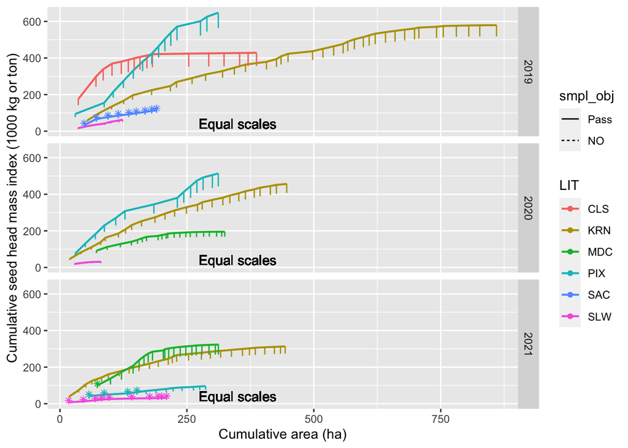

## Bigger figures of the same data

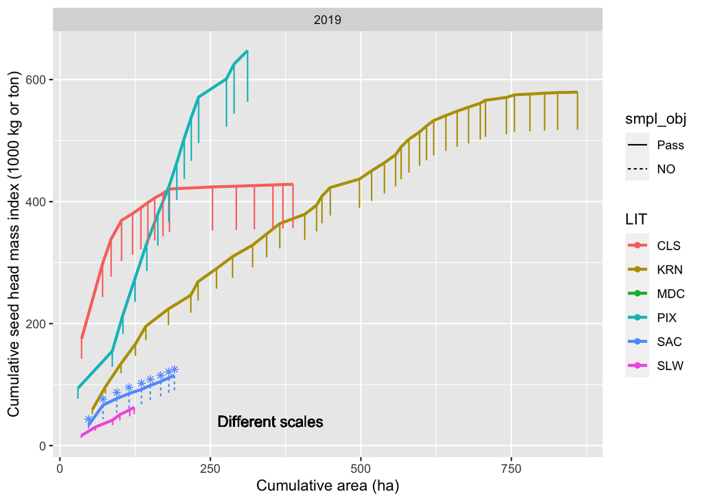

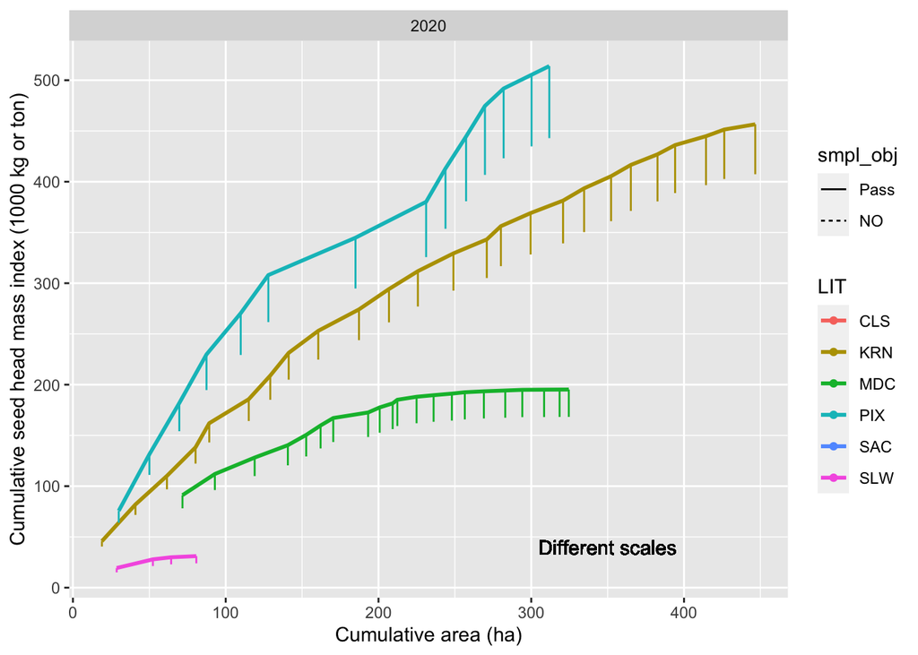

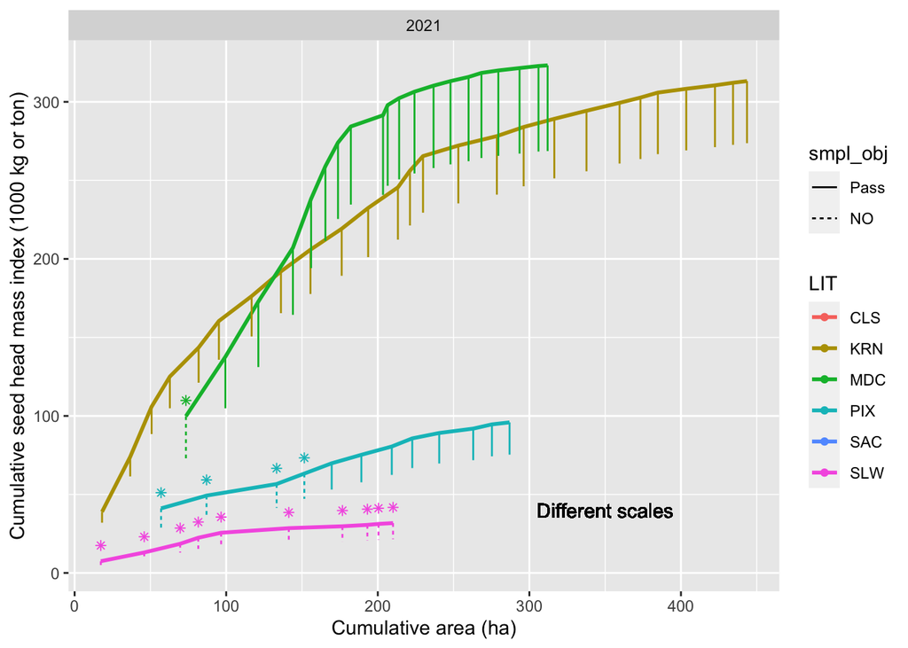

## Cumulative tables

These tables contain the data used for the figures above. Each unit that has a values equal to “Pass” in the last column meets sampling objectives. Each refuge whose last unit has a value equal to “Pass” also meets sampling objectives. Cumulative mass is calculated by adding mas contributed by each unit within refuges after units are sorted within refuges in decreasing order of total mass contributed.

The following definitions apply to the next set of tables:

Refuge: 3-letter refuge identification.

Unit: identification code for management subunit.

RtCI90_lwr (ton): Lower boundary above which 90% of the sampling distribution of cumulative seed head mass index lies. This is a non-central confidence interval that ranges from RtCI90_lwr to plus infinity.

CI90lwr (ton): Lower boundary of the central 90% confidence interval for the cumulative seed head mass index.

Cumulative Mass (ton): Estimated total seed mass index in all units above and in the line considered. For example, it is estimated that units CLS_T13A_T13A, CLS_T17_T17 and CLS_T15_T15:1 had a total of 339 tons of seed head mass index in 2019. 339 is teh value located in the line for CLS_T15_T15:1 and the column labeled Cumulative Mass (ton).

Unit Mass (ton): Estimated total seed mass index in the unit.

CI90upr (ton): Upper boundary of the central 90% confidence interval for the cumulative seed mass index.

Cumulative Area (ha): Total area of all units above and in the line considered.

Objective: Indicator of whether the unit meets the desired precision according to sampling objectives.

Mass (g/m2): Estimated seed head mass index per unit area in the subunit.

SE (g/m2): Standard error of the previous column.

CI90lwr (g/m2): Lower boundary of the central 90% confidence interval for the estimated seed head mass index per unit area in the subunit.

CI90upr (g/m2): Upper boundary of the central 90% confidence interval for the estimated seed head mass index per unit area in the subunit.

Cumulative and individual unit seed head mass index for all species in 2019 (g/m2)

| Refuge | Unit | RtCI90_lwr (ton) | CI90lwr (ton) | Cumulative Mass (ton) | Unit Mass (ton) | CI90upr (ton) | MOE/Mean | Cumulative Area (ha) | Objective | Mass (g/m2) | SE (g/m2) | CI90lwr (g/m2) | CI90upr (g/m2) |
| --- | --- | --- | --- | --- | --- | --- | --- | --- | --- | --- | --- | --- | --- |
| CLS | CLS_T13A_T13A | 142 | 134 | 175 | 175 | 221 | 0.19 | 36 | Pass | 486 | 74.0 | 372 | 613 |
| CLS | CLS_T17_T17 | 244 | 230 | 298 | 123 | 374 | 0.18 | 71 | Pass | 353 | 53.5 | 272 | 448 |
| CLS | CLS_T15_T15:1 | 277 | 263 | 339 | 41 | 424 | 0.18 | 85 | Pass | 286 | 45.8 | 217 | 368 |
| CLS | CLS_T10_T10:3 | 302 | 288 | 369 | 31 | 461 | 0.18 | 102 | Pass | 176 | 23.3 | 141 | 217 |
| CLS | CLS_T6_T6:3 | 313 | 298 | 380 | 11 | 474 | 0.18 | 121 | Pass | 60 | 6.7 | 50 | 72 |
| CLS | CLS_T6_T6:2 | 322 | 307 | 390 | 10 | 484 | 0.17 | 135 | Pass | 70 | 6.8 | 59 | 81 |
| CLS | CLS_T6_T6:4 | 329 | 315 | 398 | 8 | 494 | 0.17 | 146 | Pass | 73 | 6.9 | 62 | 85 |
| CLS | CLS_T24_T24:5 | 336 | 321 | 406 | 8 | 502 | 0.17 | 158 | Pass | 67 | 7.6 | 55 | 80 |
| CLS | CLS_T24_T24:4 | 343 | 328 | 413 | 7 | 510 | 0.17 | 171 | Pass | 55 | 6.4 | 45 | 66 |
| CLS | CLS_T6_T6:1 | 350 | 335 | 421 | 7 | 518 | 0.17 | 182 | Pass | 68 | 7.8 | 56 | 82 |
| CLS | CLS_T27_T27.3 | 353 | 338 | 424 | 3 | 522 | 0.17 | 254 | Pass | 5 | 1.0 | 3 | 6 |
| CLS | CLS_T5_T5 | 354 | 338 | 425 | 1 | 524 | 0.17 | 293 | Pass | 3 | 0.6 | 2 | 4 |
| CLS | CLS_T15_T15:3 | 355 | 339 | 426 | 1 | 525 | 0.17 | 323 | Pass | 4 | 0.7 | 3 | 5 |
| CLS | CLS_T15_T15:4 | 355 | 340 | 427 | 1 | 526 | 0.17 | 354 | Pass | 3 | 0.5 | 2 | 4 |
| CLS | CLS_T15_T15:2 | 356 | 341 | 428 | 1 | 527 | 0.17 | 371 | Pass | 4 | 0.8 | 3 | 6 |
| CLS | CLS_T6A_T6A | 356 | 341 | 428 | 0 | 528 | 0.17 | 387 | Pass | 3 | 0.5 | 2 | 4 |
| KRN | KRN_14_14G-1 | 52 | 50 | 59 | 59 | 69 | 0.12 | 54 | Pass | 109 | 10.9 | 92 | 128 |
| KRN | KRN_4A_4A-5 | 85 | 82 | 97 | 38 | 112 | 0.12 | 76 | Pass | 173 | 18.5 | 144 | 206 |
| KRN | KRN_4B_4B-1 | 119 | 115 | 135 | 38 | 155 | 0.12 | 102 | Pass | 146 | 14.2 | 124 | 171 |
| KRN | KRN_14_14C-2 | 147 | 142 | 167 | 32 | 194 | 0.12 | 125 | Pass | 134 | 19.2 | 105 | 169 |
| KRN | KRN_4A_4A-2 | 173 | 167 | 196 | 29 | 228 | 0.12 | 143 | Pass | 167 | 17.5 | 140 | 198 |
| KRN | KRN_14_14C-1 | 198 | 191 | 224 | 28 | 261 | 0.12 | 180 | Pass | 76 | 12.1 | 57 | 97 |
| KRN | KRN_14_14B-2 | 218 | 211 | 247 | 23 | 287 | 0.12 | 218 | Pass | 61 | 8.6 | 47 | 76 |
| KRN | KRN_5B_5B-7 | 238 | 230 | 269 | 22 | 312 | 0.12 | 230 | Pass | 184 | 18.3 | 155 | 216 |
| KRN | KRN_14_14B-1 | 257 | 249 | 290 | 21 | 335 | 0.11 | 260 | Pass | 70 | 8.1 | 57 | 83 |
| KRN | KRN_4A_4A-6 | 275 | 266 | 310 | 20 | 358 | 0.11 | 287 | Pass | 74 | 7.9 | 62 | 88 |
| KRN | KRN_14_14D-1 | 292 | 283 | 329 | 19 | 379 | 0.11 | 320 | Pass | 57 | 9.1 | 43 | 72 |
| KRN | KRN_5B_5B-3 | 309 | 299 | 347 | 18 | 400 | 0.11 | 343 | Pass | 78 | 9.0 | 64 | 94 |
| KRN | KRN_6A_6A-1 | 323 | 313 | 364 | 17 | 420 | 0.11 | 365 | Pass | 78 | 10.1 | 62 | 95 |
| KRN | KRN_14_14-F | 337 | 326 | 379 | 15 | 437 | 0.11 | 407 | Pass | 37 | 7.7 | 25 | 51 |

[output cut: 52 more lines]

Cumulative and individual unit seed head mass index for all species in 2020 (g/m2)

| Refuge | Unit | RtCI90_lwr (ton) | CI90lwr (ton) | Cumulative Mass (ton) | Unit Mass (ton) | CI90upr (ton) | MOE/Mean | Cumulative Area (ha) | Objective | Mass (g/m2) | SE (g/m2) | CI90lwr (g/m2) | CI90upr (g/m2) |
| --- | --- | --- | --- | --- | --- | --- | --- | --- | --- | --- | --- | --- | --- |
| KRN | KRN_4B_4B-3 | 40 | 39 | 46 | 46 | 53 | 0.12 | 19 | Pass | 241 | 22.6 | 206 | 279 |
| KRN | KRN_4A_4A-5 | 72 | 69 | 82 | 36 | 97 | 0.12 | 41 | Pass | 165 | 20.9 | 132 | 202 |
| KRN | KRN_4A_4A-4 | 97 | 94 | 110 | 28 | 129 | 0.12 | 62 | Pass | 137 | 12.1 | 118 | 157 |
| KRN | KRN_5A_5A-1 | 122 | 118 | 138 | 28 | 160 | 0.12 | 80 | Pass | 150 | 12.6 | 130 | 172 |
| KRN | KRN_4A_4A-3 | 143 | 138 | 162 | 24 | 188 | 0.12 | 89 | Pass | 265 | 26.8 | 223 | 310 |
| KRN | KRN_4B_4B-1 | 164 | 159 | 186 | 24 | 215 | 0.12 | 115 | Pass | 92 | 8.8 | 78 | 107 |
| KRN | KRN_5A_5A-6 | 185 | 179 | 209 | 23 | 242 | 0.11 | 129 | Pass | 165 | 14.7 | 143 | 191 |
| KRN | KRN_5B_5B-7 | 205 | 199 | 231 | 22 | 267 | 0.11 | 141 | Pass | 186 | 17.2 | 159 | 215 |
| KRN | KRN_5B_5B-8 | 225 | 218 | 253 | 22 | 291 | 0.11 | 161 | Pass | 112 | 9.2 | 97 | 128 |
| KRN | KRN_4A_4A-6 | 244 | 236 | 274 | 21 | 315 | 0.11 | 187 | Pass | 79 | 7.8 | 67 | 93 |
| KRN | KRN_5A_5A-7 | 261 | 253 | 294 | 20 | 338 | 0.11 | 207 | Pass | 102 | 13.4 | 82 | 125 |
| KRN | KRN_5A_5A-4 | 277 | 269 | 312 | 18 | 358 | 0.11 | 226 | Pass | 93 | 10.5 | 77 | 111 |
| KRN | KRN_5B_5B-3 | 293 | 284 | 329 | 18 | 379 | 0.11 | 249 | Pass | 75 | 11.2 | 59 | 95 |
| KRN | KRN_6A_6A-1 | 305 | 296 | 343 | 14 | 394 | 0.11 | 271 | Pass | 63 | 5.2 | 54 | 72 |
| KRN | KRN_5B_5B-1 | 317 | 307 | 356 | 13 | 409 | 0.11 | 280 | Pass | 142 | 13.3 | 121 | 164 |
| KRN | KRN_4A_4A-1 | 328 | 318 | 369 | 13 | 424 | 0.11 | 300 | Pass | 66 | 6.5 | 57 | 77 |
| KRN | KRN_5A_5A-3 | 339 | 329 | 381 | 12 | 438 | 0.11 | 321 | Pass | 58 | 5.6 | 49 | 67 |
| KRN | KRN_6A_6A-5 | 350 | 340 | 393 | 12 | 452 | 0.11 | 335 | Pass | 88 | 6.8 | 77 | 99 |
| KRN | KRN_4B_4B-2 | 361 | 350 | 405 | 12 | 465 | 0.11 | 352 | Pass | 68 | 5.9 | 58 | 78 |
| KRN | KRN_5B_5B-6 | 371 | 360 | 417 | 11 | 477 | 0.11 | 365 | Pass | 86 | 6.9 | 75 | 98 |
| KRN | KRN_4A_4A-2 | 381 | 369 | 427 | 10 | 490 | 0.11 | 383 | Pass | 60 | 9.5 | 45 | 76 |
| KRN | KRN_6A_6A-4 | 389 | 377 | 436 | 9 | 500 | 0.11 | 394 | Pass | 79 | 6.5 | 69 | 90 |
| KRN | KRN_6A_6A-2 | 397 | 384 | 445 | 9 | 510 | 0.11 | 414 | Pass | 43 | 5.1 | 35 | 52 |
| KRN | KRN_5B_5B-2 | 403 | 390 | 451 | 7 | 517 | 0.11 | 426 | Pass | 55 | 4.6 | 48 | 63 |
| KRN | KRN_5B_5B-5 | 407 | 394 | 457 | 5 | 523 | 0.11 | 447 | Pass | 26 | 3.2 | 20 | 31 |
| MDC | MDC_Duck Ponds_Duck Ponds | 78 | 74 | 91 | 91 | 109 | 0.14 | 72 | Pass | 127 | 14.7 | 104 | 152 |
| MDC | MDC_Upper Goose Pond_Upper Goose Pond | 96 | 92 | 112 | 21 | 134 | 0.14 | 93 | Pass | 98 | 13.3 | 78 | 121 |
| MDC | MDC_Gadwall_Gadwall | 110 | 105 | 128 | 16 | 153 | 0.14 | 119 | Pass | 62 | 8.8 | 49 | 77 |
| MDC | MDC_Flournoy Pond_Flournoy Pond | 120 | 115 | 140 | 12 | 167 | 0.14 | 141 | Pass | 56 | 8.4 | 43 | 71 |
| MDC | MDC_Matney 3_Matney 3 | 129 | 124 | 150 | 10 | 180 | 0.14 | 153 | Pass | 84 | 12.0 | 66 | 105 |
| MDC | MDC_Matney 6_Matney 6 | 137 | 131 | 160 | 9 | 191 | 0.14 | 162 | Pass | 99 | 12.9 | 79 | 121 |
| MDC | MDC_Matney 4 North_Matney 4 North | 143 | 137 | 167 | 7 | 200 | 0.14 | 170 | Pass | 89 | 11.3 | 72 | 108 |
| MDC | MDC_J Pond_J Pond | 148 | 142 | 173 | 5 | 206 | 0.14 | 193 | Pass | 24 | 3.2 | 19 | 30 |
| MDC | MDC_Matney 4 South_Matney 4 South | 153 | 146 | 178 | 5 | 212 | 0.14 | 201 | Pass | 66 | 8.9 | 52 | 81 |
| MDC | MDC_South Dam Pond_South Dam Pond | 156 | 149 | 182 | 4 | 216 | 0.14 | 209 | Pass | 47 | 6.5 | 37 | 58 |
| MDC | MDC_House Field_House Field | 159 | 152 | 185 | 4 | 221 | 0.14 | 212 | Pass | 115 | 13.2 | 94 | 138 |
| MDC | MDC_Matney 8_Matney 8 | 162 | 155 | 188 | 3 | 224 | 0.14 | 225 | Pass | 24 | 3.5 | 18 | 30 |
| MDC | MDC_Grandma Tract 9_Grandma Tract 9 | 163 | 156 | 190 | 2 | 226 | 0.14 | 236 | Pass | 14 | 3.3 | 9 | 20 |
| MDC | MDC_Grandma Tract 4_Grandma Tract 4 | 165 | 158 | 191 | 2 | 228 | 0.14 | 248 | Pass | 13 | 2.6 | 9 | 18 |
| MDC | MDC_Grandma Tract 2_Grandma Tract 2 | 166 | 159 | 193 | 1 | 229 | 0.14 | 257 | Pass | 16 | 2.6 | 12 | 20 |
| MDC | MDC_Grandma Tract 3_Grandma Tract 3 | 167 | 160 | 193 | 1 | 230 | 0.14 | 269 | Pass | 8 | 1.6 | 5 | 10 |
| MDC | MDC_Grandma Tract 10_Grandma Tract 10 | 167 | 160 | 194 | 1 | 231 | 0.14 | 283 | Pass | 6 | 0.7 | 4 | 7 |
| MDC | MDC_Grandma Tract 8_Grandma Tract 8 | 168 | 161 | 195 | 1 | 232 | 0.14 | 294 | Pass | 6 | 0.8 | 5 | 7 |
| MDC | MDC_Grandma Tract 7_Grandma Tract 7 | 168 | 161 | 195 | 0 | 232 | 0.14 | 308 | Pass | 1 | 0.2 | 1 | 2 |
| MDC | MDC_Matney 7_Matney 7 | 168 | 161 | 195 | 0 | 232 | 0.14 | 319 | Pass | 1 | 0.2 | 1 | 1 |
| MDC | MDC_Grandma Tract 11_Grandma Tract 11 | 168 | 161 | 195 | 0 | 232 | 0.14 | 325 | Pass | 1 | 0.2 | 1 | 1 |
| PIX | PIX_3A_3A | 64 | 62 | 76 | 76 | 92 | 0.16 | 30 | Pass | 253 | 30.7 | 205 | 305 |
| PIX | PIX_2_2 | 111 | 107 | 131 | 56 | 159 | 0.16 | 50 | Pass | 277 | 33.5 | 226 | 335 |
| PIX | PIX_3_3 | 154 | 148 | 182 | 50 | 219 | 0.15 | 70 | Pass | 258 | 30.8 | 210 | 311 |
| PIX | PIX_8B_8B | 195 | 188 | 230 | 48 | 277 | 0.15 | 87 | Pass | 269 | 31.7 | 221 | 323 |
| PIX | PIX_2A_2A | 229 | 221 | 270 | 41 | 325 | 0.15 | 110 | Pass | 181 | 21.4 | 148 | 219 |
| PIX | PIX_4_4 | 262 | 253 | 308 | 38 | 370 | 0.15 | 128 | Pass | 208 | 22.5 | 173 | 246 |
| PIX | PIX_1_1 | 295 | 284 | 345 | 37 | 412 | 0.14 | 185 | Pass | 65 | 7.0 | 54 | 77 |
| PIX | PIX_6_6 | 326 | 314 | 380 | 35 | 455 | 0.14 | 231 | Pass | 77 | 11.8 | 59 | 98 |
| PIX | PIX_7A_7A | 354 | 341 | 413 | 33 | 494 | 0.14 | 244 | Pass | 259 | 31.1 | 211 | 312 |
| PIX | PIX_9B_9B | 381 | 367 | 445 | 32 | 532 | 0.14 | 257 | Pass | 234 | 26.4 | 193 | 279 |
| PIX | PIX_9A_9A | 407 | 392 | 475 | 30 | 567 | 0.14 | 270 | Pass | 244 | 27.3 | 202 | 291 |
| PIX | PIX_7B_7B | 423 | 407 | 492 | 17 | 586 | 0.14 | 282 | Pass | 140 | 44.8 | 79 | 222 |
| PIX | PIX_4A_4A | 435 | 418 | 505 | 14 | 602 | 0.14 | 300 | Pass | 74 | 24.1 | 40 | 119 |
| PIX | PIX_8A_8A | 443 | 425 | 514 | 9 | 612 | 0.14 | 312 | Pass | 74 | 24.5 | 41 | 119 |
| SLW | SLW_LIC_57 | 15 | 14 | 19 | 19 | 26 | 0.22 | 29 | Pass | 68 | 12.4 | 49 | 90 |
| SLW | SLW_Lewis 6_22 | 21 | 20 | 28 | 9 | 38 | 0.24 | 52 | Pass | 36 | 14.6 | 18 | 64 |
| SLW | SLW_Lewis 1_22 | 23 | 21 | 30 | 2 | 41 | 0.23 | 64 | Pass | 17 | 3.8 | 12 | 24 |
| SLW | SLW_Beach Lake 1_Beach Lake 1 | 24 | 22 | 31 | 1 | 42 | 0.23 | 81 | Pass | 7 | 1.4 | 5 | 10 |

Cumulative and individual unit seed head mass index for all species in 2021 (g/m2)

| Refuge | Unit | RtCI90_lwr (ton) | CI90lwr (ton) | Cumulative Mass (ton) | Unit Mass (ton) | CI90upr (ton) | MOE/Mean | Cumulative Area (ha) | Objective | Mass (g/m2) | SE (g/m2) | CI90lwr (g/m2) | CI90upr (g/m2) |
| --- | --- | --- | --- | --- | --- | --- | --- | --- | --- | --- | --- | --- | --- |
| KRN | KRN_4A_4A-5 | 32 | 30 | 39 | 39 | 49 | 0.18 | 18 | Pass | 215 | 31.0 | 168 | 268 |
| KRN | KRN_4A_4A-7 | 61 | 58 | 74 | 35 | 92 | 0.17 | 37 | Pass | 188 | 26.3 | 148 | 234 |
| KRN | KRN_5A_5A-6 | 88 | 84 | 106 | 32 | 130 | 0.16 | 51 | Pass | 226 | 30.9 | 179 | 280 |
| KRN | KRN_5B_5B-7 | 105 | 100 | 125 | 19 | 153 | 0.16 | 63 | Pass | 159 | 22.6 | 125 | 199 |
| KRN | KRN_4B_4B-3 | 121 | 116 | 144 | 18 | 175 | 0.16 | 82 | Pass | 97 | 15.1 | 75 | 124 |
| KRN | KRN_5A_5A-5 | 136 | 130 | 160 | 17 | 195 | 0.15 | 95 | Pass | 126 | 16.5 | 102 | 156 |
| KRN | KRN_6A_6A-3 | 151 | 144 | 176 | 16 | 212 | 0.15 | 117 | Pass | 73 | 9.4 | 59 | 90 |
| KRN | KRN_5B_5B-8 | 165 | 159 | 192 | 16 | 229 | 0.14 | 136 | Pass | 81 | 10.7 | 65 | 100 |
| KRN | KRN_4A_4A-1 | 178 | 171 | 206 | 14 | 245 | 0.14 | 156 | Pass | 71 | 11.9 | 53 | 92 |
| KRN | KRN_4A_4A-4 | 189 | 183 | 219 | 13 | 260 | 0.14 | 176 | Pass | 65 | 11.5 | 48 | 85 |
| KRN | KRN_4A_4A-2 | 201 | 194 | 232 | 13 | 276 | 0.14 | 194 | Pass | 76 | 12.3 | 57 | 98 |
| KRN | KRN_5A_5A-7 | 212 | 205 | 246 | 13 | 292 | 0.14 | 213 | Pass | 67 | 13.2 | 48 | 91 |
| KRN | KRN_4A_4A-3 | 221 | 213 | 256 | 11 | 305 | 0.14 | 221 | Pass | 134 | 22.5 | 99 | 174 |
| KRN | KRN_4B_4B-4 | 229 | 221 | 265 | 9 | 315 | 0.14 | 230 | Pass | 108 | 13.0 | 88 | 131 |
| KRN | KRN_5B_5B-3 | 235 | 227 | 272 | 7 | 323 | 0.14 | 253 | Pass | 29 | 5.0 | 21 | 38 |
| KRN | KRN_4A_4A-6 | 241 | 233 | 278 | 6 | 330 | 0.13 | 279 | Pass | 24 | 3.5 | 18 | 30 |
| KRN | KRN_4B_4B-2 | 246 | 238 | 284 | 6 | 336 | 0.13 | 296 | Pass | 33 | 7.7 | 22 | 47 |
| KRN | KRN_6A_6A-2 | 251 | 242 | 289 | 5 | 342 | 0.13 | 316 | Pass | 26 | 3.3 | 21 | 32 |
| KRN | KRN_5A_5A-3 | 256 | 247 | 294 | 5 | 348 | 0.13 | 338 | Pass | 24 | 5.5 | 16 | 34 |
| KRN | KRN_6A_6A-1 | 261 | 252 | 299 | 5 | 353 | 0.13 | 359 | Pass | 23 | 3.1 | 18 | 28 |
| KRN | KRN_6A_6A-5 | 264 | 255 | 303 | 3 | 357 | 0.13 | 373 | Pass | 24 | 3.0 | 20 | 30 |
| KRN | KRN_6A_6A-4 | 267 | 258 | 306 | 3 | 360 | 0.13 | 385 | Pass | 28 | 3.1 | 23 | 33 |
| KRN | KRN_5A_5A-1 | 269 | 261 | 308 | 2 | 363 | 0.13 | 404 | Pass | 13 | 1.7 | 10 | 16 |
| KRN | KRN_5A_5A-4 | 271 | 263 | 311 | 2 | 365 | 0.13 | 422 | Pass | 12 | 1.4 | 9 | 14 |
| KRN | KRN_5B_5B-2 | 273 | 264 | 312 | 2 | 367 | 0.13 | 434 | Pass | 14 | 2.3 | 10 | 18 |
| KRN | KRN_5B_5B-1 | 274 | 265 | 313 | 1 | 368 | 0.13 | 444 | Pass | 12 | 1.6 | 9 | 14 |
| MDC | MDC_Lower Goose Pond_Lower Goose Pond | 73 | 67 | 100 | 100 | 141 | 0.27 | 73 | NO | 136 | 31.0 | 92 | 192 |
| MDC | MDC_Gadwall_Gadwall | 105 | 98 | 138 | 38 | 187 | 0.24 | 99 | Pass | 145 | 26.6 | 107 | 193 |
| MDC | MDC_Flournoy Pond_Flournoy Pond | 131 | 123 | 173 | 35 | 236 | 0.24 | 121 | Pass | 162 | 41.1 | 105 | 238 |
| MDC | MDC_J Pond_J Pond | 164 | 155 | 207 | 34 | 273 | 0.21 | 144 | Pass | 150 | 23.4 | 115 | 191 |
| MDC | MDC_Matney 3_Matney 3 | 194 | 183 | 238 | 31 | 307 | 0.18 | 156 | Pass | 260 | 37.2 | 201 | 324 |
| MDC | MDC_Matney 6_Matney 6 | 211 | 200 | 259 | 21 | 332 | 0.18 | 165 | Pass | 220 | 31.2 | 172 | 276 |
| MDC | MDC_Matney 4 North_Matney 4 North | 225 | 213 | 274 | 15 | 348 | 0.18 | 174 | Pass | 181 | 23.7 | 144 | 222 |
| MDC | MDC_South Dam Pond_South Dam Pond | 235 | 222 | 284 | 10 | 360 | 0.17 | 182 | Pass | 121 | 17.4 | 94 | 151 |
| MDC | MDC_Upper Goose Pond_Upper Goose Pond | 241 | 228 | 291 | 7 | 368 | 0.17 | 203 | Pass | 34 | 6.0 | 25 | 44 |
| MDC | MDC_House Field_House Field | 247 | 234 | 298 | 6 | 375 | 0.17 | 207 | Pass | 211 | 26.8 | 168 | 257 |
| MDC | MDC_Matney 4 South_Matney 4 South | 251 | 238 | 302 | 4 | 380 | 0.17 | 214 | Pass | 59 | 9.4 | 44 | 75 |
| MDC | MDC_Matney 7_Matney 7 | 254 | 241 | 306 | 4 | 385 | 0.17 | 224 | Pass | 41 | 5.1 | 33 | 50 |
| MDC | MDC_Matney 8_Matney 8 | 258 | 245 | 310 | 4 | 388 | 0.17 | 237 | Pass | 30 | 6.4 | 22 | 42 |
| MDC | MDC_Grandma Tract 8_Grandma Tract 8 | 260 | 247 | 313 | 3 | 392 | 0.17 | 248 | Pass | 26 | 5.3 | 18 | 36 |
| MDC | MDC_Grandma Tract 4_Grandma Tract 4 | 262 | 249 | 316 | 3 | 395 | 0.17 | 260 | Pass | 22 | 5.2 | 15 | 32 |
| MDC | MDC_Grandma Tract 2_Grandma Tract 2 | 264 | 251 | 318 | 3 | 399 | 0.17 | 268 | Pass | 30 | 6.2 | 22 | 41 |
| MDC | MDC_Grandma Tract 9_Grandma Tract 9 | 266 | 253 | 320 | 2 | 401 | 0.17 | 280 | Pass | 14 | 2.1 | 11 | 18 |
| MDC | MDC_Grandma Tract 10_Grandma Tract 10 | 267 | 254 | 322 | 2 | 403 | 0.17 | 294 | Pass | 11 | 1.6 | 8 | 14 |
| MDC | MDC_Grandma Tract 3_Grandma Tract 3 | 268 | 255 | 323 | 1 | 404 | 0.17 | 306 | Pass | 11 | 1.8 | 8 | 14 |
| MDC | MDC_Grandma Tract 11_Grandma Tract 11 | 269 | 255 | 323 | 0 | 405 | 0.17 | 312 | Pass | 7 | 1.0 | 5 | 9 |
| PIX | PIX_1_1 | 27 | 25 | 41 | 41 | 64 | 0.34 | 57 | NO | 72 | 21.0 | 43 | 112 |
| PIX | PIX_3A_3A | 35 | 32 | 49 | 8 | 73 | 0.29 | 87 | NO | 27 | 4.3 | 21 | 34 |
| PIX | PIX_6_6 | 41 | 38 | 57 | 7 | 81 | 0.27 | 133 | NO | 16 | 2.8 | 12 | 21 |
| PIX | PIX_4A_4A | 47 | 44 | 63 | 7 | 89 | 0.26 | 152 | NO | 36 | 6.2 | 27 | 48 |
| PIX | PIX_4_4 | 53 | 50 | 70 | 7 | 96 | 0.24 | 170 | Pass | 36 | 6.2 | 27 | 47 |
| PIX | PIX_3_3 | 58 | 54 | 75 | 5 | 103 | 0.23 | 189 | Pass | 28 | 6.8 | 18 | 40 |
| PIX | PIX_2_2 | 62 | 59 | 81 | 5 | 109 | 0.22 | 209 | Pass | 26 | 3.8 | 21 | 33 |
| PIX | PIX_9B_9B | 67 | 63 | 86 | 5 | 116 | 0.22 | 223 | Pass | 38 | 7.3 | 28 | 52 |
| PIX | PIX_8B_8B | 70 | 66 | 89 | 3 | 120 | 0.22 | 241 | Pass | 19 | 3.5 | 14 | 26 |
| PIX | PIX_2A_2A | 72 | 68 | 92 | 3 | 123 | 0.22 | 263 | Pass | 12 | 3.8 | 7 | 19 |
| PIX | PIX_9A_9A | 74 | 70 | 95 | 3 | 127 | 0.22 | 275 | Pass | 22 | 3.5 | 17 | 28 |
| PIX | PIX_8A_8A | 75 | 71 | 96 | 1 | 128 | 0.21 | 287 | Pass | 11 | 2.0 | 8 | 14 |
| SLW | SLW_Lewis 2_Lewis 2 | 4 | 4 | 7 | 7 | 14 | 0.43 | 17 | NO | 43 | 18.5 | 22 | 79 |
| SLW | SLW_LIC_57 | 9 | 8 | 13 | 6 | 20 | 0.31 | 46 | NO | 19 | 4.0 | 14 | 27 |
| SLW | SLW_Lewis 6_22 | 13 | 12 | 19 | 6 | 29 | 0.30 | 70 | NO | 23 | 7.2 | 14 | 37 |
| SLW | SLW_Lewis 1_22 | 15 | 14 | 22 | 4 | 36 | 0.32 | 82 | NO | 32 | 13.9 | 16 | 59 |
| SLW | SLW_Beach Lake 2_Beach Lake 2 | 17 | 16 | 26 | 3 | 41 | 0.32 | 97 | NO | 21 | 8.2 | 12 | 36 |
| SLW | SLW_HQ-6_HQ-6 | 19 | 17 | 29 | 3 | 46 | 0.33 | 141 | NO | 7 | 3.2 | 3 | 13 |
| SLW | SLW_HQ-7_27a | 20 | 18 | 30 | 1 | 48 | 0.33 | 177 | NO | 3 | 1.5 | 2 | 6 |
| SLW | SLW_Beach Lake 1_Beach Lake 1 | 21 | 19 | 31 | 1 | 49 | 0.33 | 193 | NO | 5 | 1.1 | 4 | 7 |
| SLW | SLW_Beach Lake 3_Beach Lake 3 | 21 | 19 | 31 | 1 | 50 | 0.32 | 200 | NO | 8 | 1.5 | 6 | 11 |
| SLW | SLW_HQ-5_HQ-5 | 21 | 20 | 32 | 1 | 51 | 0.32 | 210 | NO | 6 | 2.5 | 3 | 10 |

## Seed head mass index per area for units

### All species together

Some of the columns in these tables were also included in the previous tables.

Average seed head mass index for all species in 2019 (g/m2)

| Unit | Mass (g/m2) | SE (g/m2) | CI90lwr (g/m2) | CI90upr (g/m2) | RtCI90_lwr (g/m2) | MOE/Mean |
| --- | --- | --- | --- | --- | --- | --- |
| CLS_T10_T10:3 | 176 | 23.3 | 141 | 217 | 147 | 0.16 |
| CLS_T13A_T13A | 486 | 74.0 | 372 | 613 | 395 | 0.19 |
| CLS_T15_T15:1 | 286 | 45.8 | 217 | 368 | 230 | 0.20 |
| CLS_T15_T15:2 | 4 | 0.8 | 3 | 6 | 3 | 0.23 |
| CLS_T15_T15:3 | 4 | 0.7 | 3 | 5 | 3 | 0.21 |
| CLS_T15_T15:4 | 3 | 0.5 | 2 | 4 | 2 | 0.20 |
| CLS_T17_T17 | 353 | 53.5 | 272 | 448 | 287 | 0.19 |
| CLS_T24_T24:4 | 55 | 6.4 | 45 | 66 | 46 | 0.15 |
| CLS_T24_T24:5 | 67 | 7.6 | 55 | 80 | 57 | 0.14 |
| CLS_T27_T27.3 | 5 | 1.0 | 3 | 6 | 3 | 0.26 |
| CLS_T5_T5 | 3 | 0.6 | 2 | 4 | 2 | 0.24 |
| CLS_T6_T6:1 | 68 | 7.8 | 56 | 82 | 58 | 0.14 |
| CLS_T6_T6:2 | 70 | 6.8 | 59 | 81 | 61 | 0.12 |
| CLS_T6_T6:3 | 60 | 6.7 | 50 | 72 | 52 | 0.14 |
| CLS_T6_T6:4 | 73 | 6.9 | 62 | 85 | 64 | 0.12 |
| CLS_T6A_T6A | 3 | 0.5 | 2 | 4 | 2 | 0.22 |
| KRN_14_14-F | 37 | 7.7 | 25 | 51 | 28 | 0.25 |
| KRN_14_14A-1 | 5 | 0.7 | 4 | 6 | 4 | 0.15 |
| KRN_14_14A-2 | 5 | 0.8 | 4 | 7 | 4 | 0.18 |
| KRN_14_14B-1 | 70 | 8.1 | 57 | 83 | 59 | 0.15 |
| KRN_14_14B-2 | 61 | 8.6 | 47 | 76 | 50 | 0.17 |
| KRN_14_14C-1 | 76 | 12.1 | 57 | 97 | 61 | 0.20 |
| KRN_14_14C-2 | 134 | 19.2 | 105 | 169 | 111 | 0.18 |
| KRN_14_14D-1 | 57 | 9.1 | 43 | 72 | 46 | 0.20 |
| KRN_14_14D-2 | 5 | 0.8 | 4 | 7 | 4 | 0.18 |
| KRN_14_14E-1 | 13 | 1.6 | 11 | 16 | 11 | 0.15 |
| KRN_14_14E-2 | 2 | 0.2 | 2 | 2 | 2 | 0.17 |
| KRN_14_14G-1 | 109 | 10.9 | 92 | 128 | 96 | 0.12 |
| KRN_14_14G-2 | 29 | 5.2 | 21 | 38 | 22 | 0.22 |
| KRN_4A_4A-1 | 33 | 3.2 | 28 | 38 | 29 | 0.12 |

[output cut: 52 more lines]

Average seed head mass index for all species in 2020 (g/m2)

| Unit | Mass (g/m2) | SE (g/m2) | CI90lwr (g/m2) | CI90upr (g/m2) | RtCI90_lwr (g/m2) | MOE/Mean |
| --- | --- | --- | --- | --- | --- | --- |
| KRN_4A_4A-1 | 66 | 6.5 | 57 | 77 | 58 | 0.12 |
| KRN_4A_4A-2 | 60 | 9.5 | 45 | 76 | 48 | 0.20 |
| KRN_4A_4A-3 | 265 | 26.8 | 223 | 310 | 231 | 0.13 |
| KRN_4A_4A-4 | 137 | 12.1 | 118 | 157 | 122 | 0.11 |
| KRN_4A_4A-5 | 165 | 20.9 | 132 | 202 | 139 | 0.16 |
| KRN_4A_4A-6 | 79 | 7.8 | 67 | 93 | 70 | 0.12 |
| KRN_4B_4B-1 | 92 | 8.8 | 78 | 107 | 81 | 0.12 |
| KRN_4B_4B-2 | 68 | 5.9 | 58 | 78 | 60 | 0.11 |
| KRN_4B_4B-3 | 241 | 22.6 | 206 | 279 | 213 | 0.12 |
| KRN_5A_5A-1 | 150 | 12.6 | 130 | 172 | 134 | 0.11 |
| KRN_5A_5A-3 | 58 | 5.6 | 49 | 67 | 51 | 0.12 |
| KRN_5A_5A-4 | 93 | 10.5 | 77 | 111 | 80 | 0.14 |
| KRN_5A_5A-6 | 165 | 14.7 | 143 | 191 | 147 | 0.11 |
| KRN_5A_5A-7 | 102 | 13.4 | 82 | 125 | 86 | 0.16 |
| KRN_5B_5B-1 | 142 | 13.3 | 121 | 164 | 125 | 0.12 |
| KRN_5B_5B-2 | 55 | 4.6 | 48 | 63 | 49 | 0.10 |
| KRN_5B_5B-3 | 75 | 11.2 | 59 | 95 | 62 | 0.18 |
| KRN_5B_5B-5 | 26 | 3.2 | 20 | 31 | 22 | 0.16 |
| KRN_5B_5B-6 | 86 | 6.9 | 75 | 98 | 77 | 0.10 |
| KRN_5B_5B-7 | 186 | 17.2 | 159 | 215 | 164 | 0.12 |
| KRN_5B_5B-8 | 112 | 9.2 | 97 | 128 | 100 | 0.10 |
| KRN_6A_6A-1 | 63 | 5.2 | 54 | 72 | 56 | 0.11 |
| KRN_6A_6A-2 | 43 | 5.1 | 35 | 52 | 37 | 0.14 |
| KRN_6A_6A-4 | 79 | 6.5 | 69 | 90 | 71 | 0.10 |
| KRN_6A_6A-5 | 88 | 6.8 | 77 | 99 | 79 | 0.10 |
| MDC_Duck Ponds_Duck Ponds | 127 | 14.7 | 104 | 152 | 109 | 0.14 |
| MDC_Flournoy Pond_Flournoy Pond | 56 | 8.4 | 43 | 71 | 46 | 0.18 |
| MDC_Gadwall_Gadwall | 62 | 8.8 | 49 | 77 | 51 | 0.17 |
| MDC_Grandma Tract 10_Grandma Tract 10 | 6 | 0.7 | 4 | 7 | 5 | 0.15 |
| MDC_Grandma Tract 11_Grandma Tract 11 | 1 | 0.2 | 1 | 1 | 1 | 0.23 |
| MDC_Grandma Tract 2_Grandma Tract 2 | 16 | 2.6 | 12 | 20 | 13 | 0.20 |
| MDC_Grandma Tract 3_Grandma Tract 3 | 8 | 1.6 | 5 | 10 | 6 | 0.25 |
| MDC_Grandma Tract 4_Grandma Tract 4 | 13 | 2.6 | 9 | 18 | 10 | 0.23 |
| MDC_Grandma Tract 7_Grandma Tract 7 | 1 | 0.2 | 1 | 2 | 1 | 0.28 |
| MDC_Grandma Tract 8_Grandma Tract 8 | 6 | 0.8 | 5 | 7 | 5 | 0.18 |
| MDC_Grandma Tract 9_Grandma Tract 9 | 14 | 3.3 | 9 | 20 | 10 | 0.27 |
| MDC_House Field_House Field | 115 | 13.2 | 94 | 138 | 99 | 0.14 |
| MDC_J Pond_J Pond | 24 | 3.2 | 19 | 30 | 20 | 0.17 |
| MDC_Matney 3_Matney 3 | 84 | 12.0 | 66 | 105 | 70 | 0.17 |
| MDC_Matney 4 North_Matney 4 North | 89 | 11.3 | 72 | 108 | 75 | 0.16 |
| MDC_Matney 4 South_Matney 4 South | 66 | 8.9 | 52 | 81 | 55 | 0.17 |
| MDC_Matney 6_Matney 6 | 99 | 12.9 | 79 | 121 | 83 | 0.16 |
| MDC_Matney 7_Matney 7 | 1 | 0.2 | 1 | 1 | 1 | 0.28 |
| MDC_Matney 8_Matney 8 | 24 | 3.5 | 18 | 30 | 19 | 0.18 |
| MDC_South Dam Pond_South Dam Pond | 47 | 6.5 | 37 | 58 | 39 | 0.17 |
| MDC_Upper Goose Pond_Upper Goose Pond | 98 | 13.3 | 78 | 121 | 82 | 0.17 |
| PIX_1_1 | 65 | 7.0 | 54 | 77 | 56 | 0.14 |
| PIX_2_2 | 277 | 33.5 | 226 | 335 | 235 | 0.15 |
| PIX_2A_2A | 181 | 21.4 | 148 | 219 | 154 | 0.15 |
| PIX_3_3 | 258 | 30.8 | 210 | 311 | 219 | 0.15 |
| PIX_3A_3A | 253 | 30.7 | 205 | 305 | 214 | 0.16 |
| PIX_4_4 | 208 | 22.5 | 173 | 246 | 179 | 0.14 |
| PIX_4A_4A | 74 | 24.1 | 40 | 119 | 46 | 0.38 |
| PIX_6_6 | 77 | 11.8 | 59 | 98 | 62 | 0.19 |
| PIX_7A_7A | 259 | 31.1 | 211 | 312 | 220 | 0.15 |
| PIX_7B_7B | 140 | 44.8 | 79 | 222 | 88 | 0.37 |
| PIX_8A_8A | 74 | 24.5 | 41 | 119 | 46 | 0.38 |
| PIX_8B_8B | 269 | 31.7 | 221 | 323 | 229 | 0.15 |
| PIX_9A_9A | 244 | 27.3 | 202 | 291 | 209 | 0.14 |
| PIX_9B_9B | 234 | 26.4 | 193 | 279 | 200 | 0.14 |
| SLW_Beach Lake 1_Beach Lake 1 | 7 | 1.4 | 5 | 10 | 5 | 0.23 |
| SLW_Lewis 1_22 | 17 | 3.8 | 12 | 24 | 13 | 0.24 |
| SLW_Lewis 6_22 | 36 | 14.6 | 18 | 64 | 20 | 0.44 |
| SLW_LIC_57 | 68 | 12.4 | 49 | 90 | 52 | 0.22 |

Average seed head mass index for all species in 2021 (g/m2)

| Unit | Mass (g/m2) | SE (g/m2) | CI90lwr (g/m2) | CI90upr (g/m2) | RtCI90_lwr (g/m2) | MOE/Mean |
| --- | --- | --- | --- | --- | --- | --- |
| KRN_4A_4A-1 | 71 | 11.9 | 53 | 92 | 56 | 0.21 |
| KRN_4A_4A-2 | 76 | 12.3 | 57 | 98 | 61 | 0.20 |
| KRN_4A_4A-3 | 134 | 22.5 | 99 | 174 | 107 | 0.20 |
| KRN_4A_4A-4 | 65 | 11.5 | 48 | 85 | 51 | 0.21 |
| KRN_4A_4A-5 | 215 | 31.0 | 168 | 268 | 177 | 0.18 |
| KRN_4A_4A-6 | 24 | 3.5 | 18 | 30 | 19 | 0.18 |
| KRN_4A_4A-7 | 188 | 26.3 | 148 | 234 | 156 | 0.17 |
| KRN_4B_4B-2 | 33 | 7.7 | 22 | 47 | 24 | 0.28 |
| KRN_4B_4B-3 | 97 | 15.1 | 75 | 124 | 79 | 0.18 |
| KRN_4B_4B-4 | 108 | 13.0 | 88 | 131 | 92 | 0.15 |
| KRN_5A_5A-1 | 13 | 1.7 | 10 | 16 | 11 | 0.16 |
| KRN_5A_5A-3 | 24 | 5.5 | 16 | 34 | 18 | 0.27 |
| KRN_5A_5A-4 | 12 | 1.4 | 9 | 14 | 10 | 0.16 |
| KRN_5A_5A-5 | 126 | 16.5 | 102 | 156 | 106 | 0.16 |
| KRN_5A_5A-6 | 226 | 30.9 | 179 | 280 | 188 | 0.17 |
| KRN_5A_5A-7 | 67 | 13.2 | 48 | 91 | 51 | 0.23 |
| KRN_5B_5B-1 | 12 | 1.6 | 9 | 14 | 10 | 0.16 |
| KRN_5B_5B-2 | 14 | 2.3 | 10 | 18 | 11 | 0.20 |
| KRN_5B_5B-3 | 29 | 5.0 | 21 | 38 | 23 | 0.21 |
| KRN_5B_5B-7 | 159 | 22.6 | 125 | 199 | 131 | 0.17 |
| KRN_5B_5B-8 | 81 | 10.7 | 65 | 100 | 68 | 0.16 |
| KRN_6A_6A-1 | 23 | 3.1 | 18 | 28 | 19 | 0.16 |
| KRN_6A_6A-2 | 26 | 3.3 | 21 | 32 | 22 | 0.16 |
| KRN_6A_6A-3 | 73 | 9.4 | 59 | 90 | 62 | 0.15 |
| KRN_6A_6A-4 | 28 | 3.1 | 23 | 33 | 24 | 0.14 |
| KRN_6A_6A-5 | 24 | 3.0 | 20 | 30 | 20 | 0.15 |
| MDC_Flournoy Pond_Flournoy Pond | 162 | 41.1 | 105 | 238 | 115 | 0.29 |
| MDC_Gadwall_Gadwall | 145 | 26.6 | 107 | 193 | 114 | 0.21 |
| MDC_Grandma Tract 10_Grandma Tract 10 | 11 | 1.6 | 8 | 14 | 9 | 0.18 |
| MDC_Grandma Tract 11_Grandma Tract 11 | 7 | 1.0 | 5 | 9 | 5 | 0.19 |
| MDC_Grandma Tract 2_Grandma Tract 2 | 30 | 6.2 | 22 | 41 | 23 | 0.24 |
| MDC_Grandma Tract 3_Grandma Tract 3 | 11 | 1.8 | 8 | 14 | 8 | 0.20 |
| MDC_Grandma Tract 4_Grandma Tract 4 | 22 | 5.2 | 15 | 32 | 16 | 0.27 |
| MDC_Grandma Tract 8_Grandma Tract 8 | 26 | 5.3 | 18 | 36 | 20 | 0.24 |
| MDC_Grandma Tract 9_Grandma Tract 9 | 14 | 2.1 | 11 | 18 | 12 | 0.18 |
| MDC_House Field_House Field | 211 | 26.8 | 168 | 257 | 177 | 0.16 |
| MDC_J Pond_J Pond | 150 | 23.4 | 115 | 191 | 121 | 0.19 |
| MDC_Lower Goose Pond_Lower Goose Pond | 136 | 31.0 | 92 | 192 | 99 | 0.27 |
| MDC_Matney 3_Matney 3 | 260 | 37.2 | 201 | 324 | 213 | 0.18 |
| MDC_Matney 4 North_Matney 4 North | 181 | 23.7 | 144 | 222 | 152 | 0.16 |
| MDC_Matney 4 South_Matney 4 South | 59 | 9.4 | 44 | 75 | 47 | 0.19 |
| MDC_Matney 6_Matney 6 | 220 | 31.2 | 172 | 276 | 182 | 0.17 |
| MDC_Matney 7_Matney 7 | 41 | 5.1 | 33 | 50 | 34 | 0.15 |
| MDC_Matney 8_Matney 8 | 30 | 6.4 | 22 | 42 | 23 | 0.24 |
| MDC_South Dam Pond_South Dam Pond | 121 | 17.4 | 94 | 151 | 99 | 0.18 |
| MDC_Upper Goose Pond_Upper Goose Pond | 34 | 6.0 | 25 | 44 | 26 | 0.22 |
| PIX_1_1 | 72 | 21.0 | 43 | 112 | 48 | 0.34 |
| PIX_2_2 | 26 | 3.8 | 21 | 33 | 22 | 0.17 |
| PIX_2A_2A | 12 | 3.8 | 7 | 19 | 8 | 0.34 |
| PIX_3_3 | 28 | 6.8 | 18 | 40 | 20 | 0.28 |
| PIX_3A_3A | 27 | 4.3 | 21 | 34 | 22 | 0.19 |
| PIX_4_4 | 36 | 6.2 | 27 | 47 | 29 | 0.20 |
| PIX_4A_4A | 36 | 6.2 | 27 | 48 | 29 | 0.20 |
| PIX_6_6 | 16 | 2.8 | 12 | 21 | 13 | 0.21 |
| PIX_8A_8A | 11 | 2.0 | 8 | 14 | 8 | 0.22 |
| PIX_8B_8B | 19 | 3.5 | 14 | 26 | 15 | 0.21 |
| PIX_9A_9A | 22 | 3.5 | 17 | 28 | 18 | 0.19 |
| PIX_9B_9B | 38 | 7.3 | 28 | 52 | 30 | 0.21 |
| SLW_Beach Lake 1_Beach Lake 1 | 5 | 1.1 | 4 | 7 | 4 | 0.24 |
| SLW_Beach Lake 2_Beach Lake 2 | 21 | 8.2 | 12 | 36 | 13 | 0.39 |
| SLW_Beach Lake 3_Beach Lake 3 | 8 | 1.5 | 6 | 11 | 7 | 0.21 |
| SLW_HQ-5_HQ-5 | 6 | 2.5 | 3 | 10 | 3 | 0.45 |
| SLW_HQ-6_HQ-6 | 7 | 3.2 | 3 | 13 | 3 | 0.48 |
| SLW_HQ-7_27a | 3 | 1.5 | 2 | 6 | 2 | 0.42 |
| SLW_Lewis 1_22 | 32 | 13.9 | 16 | 59 | 18 | 0.43 |
| SLW_Lewis 2_Lewis 2 | 43 | 18.5 | 22 | 79 | 25 | 0.43 |
| SLW_Lewis 6_22 | 23 | 7.2 | 14 | 37 | 16 | 0.33 |
| SLW_LIC_57 | 19 | 4.0 | 14 | 27 | 15 | 0.23 |

### One species at a time

This set of tables shows information analogous to the previous set, but instead of showing the summ for all species, it shows one species in each table.

Average seed head mass index for Swamp_Timothy in 2019 (g/m2)

| Unit | Mass (g/m2) | SE (g/m2) | CI90lwr (g/m2) | CI90upr (g/m2) | RtCI90_lwr (g/m2) | MOE/Mean |
| --- | --- | --- | --- | --- | --- | --- |
| CLS_T10_T10:3 | 162 | 23.3 | 127 | 203 | 134 | 0.18 |
| CLS_T13A_T13A | 484 | 74.1 | 369 | 611 | 393 | 0.19 |
| CLS_T15_T15:1 | 277 | 46.2 | 208 | 359 | 221 | 0.20 |
| CLS_T15_T15:2 | 4 | 0.8 | 3 | 5 | 3 | 0.24 |
| CLS_T15_T15:3 | 3 | 0.7 | 2 | 4 | 2 | 0.25 |
| CLS_T15_T15:4 | 3 | 0.5 | 2 | 4 | 2 | 0.25 |
| CLS_T17_T17 | 348 | 53.6 | 267 | 443 | 281 | 0.19 |
| CLS_T24_T24:4 | 19 | 4.4 | 13 | 28 | 14 | 0.27 |
| CLS_T24_T24:5 | 40 | 6.7 | 30 | 52 | 32 | 0.20 |
| CLS_T27_T27.3 | 4 | 1.0 | 3 | 6 | 3 | 0.27 |
| CLS_T5_T5 | 3 | 0.6 | 2 | 4 | 2 | 0.26 |
| CLS_T6_T6:1 | 26 | 5.5 | 18 | 36 | 20 | 0.25 |
| CLS_T6_T6:2 | 30 | 4.1 | 23 | 37 | 25 | 0.17 |
| CLS_T6_T6:3 | 26 | 4.7 | 19 | 35 | 20 | 0.22 |
| CLS_T6_T6:4 | 34 | 4.8 | 27 | 42 | 28 | 0.17 |
| CLS_T6A_T6A | 3 | 0.5 | 2 | 4 | 2 | 0.23 |
| KRN_14_14-F | 36 | 7.6 | 25 | 50 | 27 | 0.25 |
| KRN_14_14A-1 | 5 | 0.6 | 4 | 6 | 4 | 0.15 |
| KRN_14_14A-2 | 5 | 0.8 | 4 | 6 | 4 | 0.17 |
| KRN_14_14B-1 | 69 | 8.0 | 57 | 83 | 59 | 0.15 |
| KRN_14_14B-2 | 60 | 8.5 | 46 | 74 | 49 | 0.18 |
| KRN_14_14C-1 | 75 | 12.0 | 56 | 96 | 60 | 0.20 |
| KRN_14_14C-2 | 134 | 19.2 | 104 | 169 | 110 | 0.18 |
| KRN_14_14D-1 | 56 | 8.9 | 42 | 72 | 45 | 0.20 |
| KRN_14_14D-2 | 5 | 0.8 | 4 | 7 | 4 | 0.19 |
| KRN_14_14E-1 | 13 | 1.6 | 11 | 16 | 11 | 0.15 |
| KRN_14_14E-2 | 2 | 0.2 | 1 | 2 | 2 | 0.14 |
| KRN_14_14G-1 | 108 | 10.8 | 91 | 127 | 94 | 0.13 |
| KRN_14_14G-2 | 28 | 5.1 | 21 | 38 | 22 | 0.22 |
| KRN_4A_4A-1 | 33 | 3.2 | 28 | 38 | 29 | 0.12 |

[output cut: 52 more lines]

Average seed head mass index for Watergrass in 2019 (g/m2)

| Unit | Mass (g/m2) | SE (g/m2) | CI90lwr (g/m2) | CI90upr (g/m2) | RtCI90_lwr (g/m2) | MOE/Mean |
| --- | --- | --- | --- | --- | --- | --- |
| CLS_T10_T10:3 | 14 | 1.7 | 11 | 17 | 12 | 0.15 |
| CLS_T13A_T13A | 3 | 0.5 | 2 | 3 | 2 | 0.21 |
| CLS_T15_T15:1 | 9 | 1.7 | 6 | 12 | 7 | 0.23 |
| CLS_T15_T15:2 | 0 | 0.1 | 0 | 0 | 0 | 0.17 |
| CLS_T15_T15:3 | 0 | 0.1 | 0 | 0 | 0 | 0.18 |
| CLS_T15_T15:4 | 0 | 0.1 | 0 | 1 | 0 | 0.32 |
| CLS_T17_T17 | 5 | 1.0 | 3 | 7 | 4 | 0.24 |
| CLS_T24_T24:4 | 35 | 4.9 | 28 | 44 | 29 | 0.17 |
| CLS_T24_T24:5 | 26 | 3.7 | 20 | 33 | 22 | 0.17 |
| CLS_T27_T27.3 | 0 | 0.1 | 0 | 1 | 0 | 0.16 |
| CLS_T5_T5 | 0 | 0.1 | 0 | 1 | 0 | 0.30 |
| CLS_T6_T6:1 | 42 | 5.9 | 32 | 52 | 34 | 0.17 |
| CLS_T6_T6:2 | 40 | 5.3 | 32 | 49 | 33 | 0.16 |
| CLS_T6_T6:3 | 34 | 5.0 | 26 | 43 | 28 | 0.18 |
| CLS_T6_T6:4 | 39 | 5.0 | 31 | 47 | 33 | 0.16 |
| CLS_T6A_T6A | 0 | 0.1 | 0 | 0 | 0 | 0.12 |
| KRN_14_14-F | 1 | 1.0 | 0 | 2 | 0 | 1.00 |
| KRN_14_14A-1 | 0 | 0.1 | 0 | 0 | 0 | 1.00 |
| KRN_14_14A-2 | 0 | 0.1 | 0 | 0 | 0 | 1.00 |
| KRN_14_14B-1 | 0 | 0.6 | 0 | 1 | 0 | 1.00 |
| KRN_14_14B-2 | 1 | 1.3 | 0 | 3 | 0 | 1.00 |
| KRN_14_14C-1 | 1 | 1.5 | 0 | 4 | 0 | 1.00 |
| KRN_14_14C-2 | 1 | 0.8 | 0 | 2 | 0 | 1.00 |
| KRN_14_14D-1 | 1 | 1.4 | 0 | 4 | 0 | 1.00 |
| KRN_14_14D-2 | 0 | 0.1 | 0 | 0 | 0 | 1.00 |
| KRN_14_14E-1 | 0 | 0.3 | 0 | 1 | 0 | 1.00 |
| KRN_14_14E-2 | 0 | 0.1 | 0 | 0 | 0 | 1.00 |
| KRN_14_14G-1 | 1 | 1.7 | 0 | 4 | 0 | 1.00 |
| KRN_14_14G-2 | 0 | 0.5 | 0 | 1 | 0 | 1.00 |
| KRN_4A_4A-1 | 0 | 0.1 | 0 | 0 | 0 | 1.00 |

[output cut: 52 more lines]

Average seed head mass index for Swamp_Timothy in 2020 (g/m2)

| Unit | Mass (g/m2) | SE (g/m2) | CI90lwr (g/m2) | CI90upr (g/m2) | RtCI90_lwr (g/m2) | MOE/Mean |
| --- | --- | --- | --- | --- | --- | --- |
| KRN_4A_4A-1 | 66 | 6.5 | 57 | 77 | 58 | 0.12 |
| KRN_4A_4A-2 | 60 | 9.5 | 45 | 76 | 48 | 0.20 |
| KRN_4A_4A-3 | 265 | 26.8 | 223 | 310 | 231 | 0.13 |
| KRN_4A_4A-4 | 137 | 12.1 | 118 | 157 | 122 | 0.11 |
| KRN_4A_4A-5 | 165 | 20.9 | 132 | 202 | 139 | 0.16 |
| KRN_4A_4A-6 | 79 | 7.8 | 67 | 93 | 70 | 0.12 |
| KRN_4B_4B-1 | 92 | 8.8 | 78 | 107 | 81 | 0.12 |
| KRN_4B_4B-2 | 68 | 5.9 | 58 | 78 | 60 | 0.11 |
| KRN_4B_4B-3 | 241 | 22.6 | 206 | 279 | 213 | 0.12 |
| KRN_5A_5A-1 | 150 | 12.6 | 130 | 172 | 134 | 0.11 |
| KRN_5A_5A-3 | 58 | 5.6 | 49 | 67 | 51 | 0.12 |
| KRN_5A_5A-4 | 93 | 10.5 | 77 | 111 | 80 | 0.14 |
| KRN_5A_5A-6 | 165 | 14.7 | 143 | 191 | 147 | 0.11 |
| KRN_5A_5A-7 | 102 | 13.4 | 82 | 125 | 86 | 0.16 |
| KRN_5B_5B-1 | 142 | 13.3 | 121 | 164 | 125 | 0.12 |
| KRN_5B_5B-2 | 55 | 4.6 | 48 | 63 | 49 | 0.10 |
| KRN_5B_5B-3 | 75 | 11.2 | 59 | 95 | 62 | 0.18 |
| KRN_5B_5B-5 | 26 | 3.2 | 20 | 31 | 22 | 0.16 |
| KRN_5B_5B-6 | 86 | 6.9 | 75 | 98 | 77 | 0.10 |
| KRN_5B_5B-7 | 186 | 17.2 | 159 | 215 | 164 | 0.12 |
| KRN_5B_5B-8 | 112 | 9.2 | 97 | 128 | 100 | 0.10 |
| KRN_6A_6A-1 | 63 | 5.2 | 54 | 72 | 56 | 0.11 |
| KRN_6A_6A-2 | 43 | 5.1 | 35 | 52 | 37 | 0.14 |
| KRN_6A_6A-4 | 79 | 6.5 | 69 | 90 | 71 | 0.10 |
| KRN_6A_6A-5 | 88 | 6.8 | 77 | 99 | 79 | 0.10 |
| MDC_Duck Ponds_Duck Ponds | 127 | 14.8 | 104 | 152 | 109 | 0.14 |
| MDC_Flournoy Pond_Flournoy Pond | 56 | 8.4 | 43 | 70 | 45 | 0.18 |
| MDC_Gadwall_Gadwall | 62 | 8.8 | 48 | 77 | 51 | 0.17 |
| MDC_Grandma Tract 10_Grandma Tract 10 | 5 | 0.7 | 4 | 7 | 4 | 0.17 |
| MDC_Grandma Tract 11_Grandma Tract 11 | 1 | 0.2 | 1 | 1 | 1 | 0.31 |
| MDC_Grandma Tract 2_Grandma Tract 2 | 14 | 2.6 | 10 | 19 | 11 | 0.22 |
| MDC_Grandma Tract 3_Grandma Tract 3 | 1 | 0.2 | 1 | 2 | 1 | 0.22 |
| MDC_Grandma Tract 4_Grandma Tract 4 | 12 | 2.5 | 9 | 17 | 9 | 0.24 |
| MDC_Grandma Tract 7_Grandma Tract 7 | 1 | 0.2 | 1 | 2 | 1 | 0.25 |
| MDC_Grandma Tract 8_Grandma Tract 8 | 5 | 0.8 | 4 | 7 | 4 | 0.18 |
| MDC_Grandma Tract 9_Grandma Tract 9 | 13 | 3.3 | 8 | 19 | 9 | 0.28 |
| MDC_House Field_House Field | 114 | 13.2 | 94 | 137 | 98 | 0.14 |
| MDC_J Pond_J Pond | 20 | 3.2 | 16 | 26 | 16 | 0.19 |
| MDC_Matney 3_Matney 3 | 84 | 12.0 | 66 | 105 | 69 | 0.17 |
| MDC_Matney 4 North_Matney 4 North | 88 | 11.3 | 71 | 107 | 74 | 0.16 |
| MDC_Matney 4 South_Matney 4 South | 64 | 8.9 | 50 | 80 | 53 | 0.17 |
| MDC_Matney 6_Matney 6 | 98 | 12.9 | 78 | 121 | 82 | 0.16 |
| MDC_Matney 7_Matney 7 | 1 | 0.2 | 1 | 1 | 1 | 0.25 |
| MDC_Matney 8_Matney 8 | 18 | 3.2 | 13 | 24 | 14 | 0.22 |
| MDC_South Dam Pond_South Dam Pond | 47 | 6.5 | 37 | 58 | 39 | 0.17 |
| MDC_Upper Goose Pond_Upper Goose Pond | 98 | 13.3 | 77 | 121 | 81 | 0.17 |
| PIX_1_1 | 53 | 6.3 | 43 | 64 | 45 | 0.15 |
| PIX_2_2 | 274 | 33.6 | 222 | 331 | 231 | 0.16 |
| PIX_2A_2A | 176 | 21.4 | 144 | 213 | 149 | 0.16 |
| PIX_3_3 | 244 | 30.8 | 197 | 297 | 205 | 0.16 |
| PIX_3A_3A | 244 | 30.8 | 197 | 298 | 205 | 0.16 |
| PIX_4_4 | 199 | 22.4 | 164 | 237 | 170 | 0.14 |
| PIX_4A_4A | 63 | 23.5 | 32 | 107 | 36 | 0.42 |
| PIX_6_6 | 67 | 11.4 | 51 | 88 | 53 | 0.21 |
| PIX_7A_7A | 258 | 31.1 | 211 | 311 | 219 | 0.15 |
| PIX_7B_7B | 12 | 1.6 | 10 | 15 | 10 | 0.17 |
| PIX_8A_8A | 63 | 23.6 | 32 | 107 | 36 | 0.42 |
| PIX_8B_8B | 267 | 31.7 | 218 | 321 | 226 | 0.15 |
| PIX_9A_9A | 233 | 27.2 | 191 | 280 | 199 | 0.15 |
| PIX_9B_9B | 230 | 26.4 | 189 | 275 | 196 | 0.15 |
| SLW_Beach Lake 1_Beach Lake 1 | 7 | 1.4 | 5 | 9 | 5 | 0.25 |
| SLW_Lewis 1_22 | 12 | 1.8 | 9 | 15 | 10 | 0.18 |
| SLW_Lewis 6_22 | 20 | 12.0 | 7 | 43 | 8 | 0.59 |
| SLW_LIC_57 | 64 | 12.2 | 46 | 86 | 49 | 0.23 |

Average seed head mass index for Watergrass in 2020 (g/m2)

| Unit | Mass (g/m2) | SE (g/m2) | CI90lwr (g/m2) | CI90upr (g/m2) | RtCI90_lwr (g/m2) | MOE/Mean |
| --- | --- | --- | --- | --- | --- | --- |
| KRN_4A_4A-1 | 0 | 0.0 | 0 | 0 | 0 | NaN |
| KRN_4A_4A-2 | 0 | 0.0 | 0 | 0 | 0 | NaN |
| KRN_4A_4A-3 | 0 | 0.0 | 0 | 0 | 0 | NaN |
| KRN_4A_4A-4 | 0 | 0.0 | 0 | 0 | 0 | NaN |
| KRN_4A_4A-5 | 0 | 0.0 | 0 | 0 | 0 | NaN |
| KRN_4A_4A-6 | 0 | 0.0 | 0 | 0 | 0 | NaN |
| KRN_4B_4B-1 | 0 | 0.0 | 0 | 0 | 0 | NaN |
| KRN_4B_4B-2 | 0 | 0.0 | 0 | 0 | 0 | NaN |
| KRN_4B_4B-3 | 0 | 0.0 | 0 | 0 | 0 | NaN |
| KRN_5A_5A-1 | 0 | 0.0 | 0 | 0 | 0 | NaN |
| KRN_5A_5A-3 | 0 | 0.0 | 0 | 0 | 0 | NaN |
| KRN_5A_5A-4 | 0 | 0.0 | 0 | 0 | 0 | NaN |
| KRN_5A_5A-6 | 0 | 0.0 | 0 | 0 | 0 | NaN |
| KRN_5A_5A-7 | 0 | 0.0 | 0 | 0 | 0 | NaN |
| KRN_5B_5B-1 | 0 | 0.0 | 0 | 0 | 0 | NaN |
| KRN_5B_5B-2 | 0 | 0.0 | 0 | 0 | 0 | NaN |
| KRN_5B_5B-3 | 0 | 0.0 | 0 | 0 | 0 | NaN |
| KRN_5B_5B-5 | 0 | 0.0 | 0 | 0 | 0 | NaN |
| KRN_5B_5B-6 | 0 | 0.0 | 0 | 0 | 0 | NaN |
| KRN_5B_5B-7 | 0 | 0.0 | 0 | 0 | 0 | NaN |
| KRN_5B_5B-8 | 0 | 0.0 | 0 | 0 | 0 | NaN |
| KRN_6A_6A-1 | 0 | 0.0 | 0 | 0 | 0 | NaN |
| KRN_6A_6A-2 | 0 | 0.0 | 0 | 0 | 0 | NaN |
| KRN_6A_6A-4 | 0 | 0.0 | 0 | 0 | 0 | NaN |
| KRN_6A_6A-5 | 0 | 0.0 | 0 | 0 | 0 | NaN |
| MDC_Duck Ponds_Duck Ponds | 0 | 0.1 | 0 | 0 | 0 | 0.40 |
| MDC_Flournoy Pond_Flournoy Pond | 1 | 0.1 | 0 | 1 | 0 | 0.28 |
| MDC_Gadwall_Gadwall | 1 | 0.1 | 0 | 1 | 0 | 0.23 |
| MDC_Grandma Tract 10_Grandma Tract 10 | 0 | 0.1 | 0 | 0 | 0 | 0.09 |
| MDC_Grandma Tract 11_Grandma Tract 11 | 0 | 0.0 | 0 | 0 | 0 | 1.00 |
| MDC_Grandma Tract 2_Grandma Tract 2 | 2 | 0.4 | 1 | 2 | 1 | 0.30 |
| MDC_Grandma Tract 3_Grandma Tract 3 | 6 | 1.6 | 4 | 9 | 4 | 0.29 |
| MDC_Grandma Tract 4_Grandma Tract 4 | 1 | 0.1 | 0 | 1 | 0 | 0.28 |
| MDC_Grandma Tract 7_Grandma Tract 7 | 0 | 0.0 | 0 | 0 | 0 | 1.00 |
| MDC_Grandma Tract 8_Grandma Tract 8 | 1 | 0.1 | 0 | 1 | 0 | 0.29 |
| MDC_Grandma Tract 9_Grandma Tract 9 | 1 | 0.2 | 1 | 1 | 1 | 0.21 |
| MDC_House Field_House Field | 0 | 0.1 | 0 | 1 | 0 | 0.19 |
| MDC_J Pond_J Pond | 4 | 0.8 | 2 | 5 | 3 | 0.26 |
| MDC_Matney 3_Matney 3 | 0 | 0.0 | 0 | 0 | 0 | 0.10 |
| MDC_Matney 4 North_Matney 4 North | 1 | 0.2 | 1 | 1 | 1 | 0.23 |
| MDC_Matney 4 South_Matney 4 South | 2 | 0.3 | 1 | 2 | 1 | 0.21 |
| MDC_Matney 6_Matney 6 | 1 | 0.1 | 0 | 1 | 0 | 0.21 |
| MDC_Matney 7_Matney 7 | 0 | 0.0 | 0 | 0 | 0 | 1.00 |
| MDC_Matney 8_Matney 8 | 5 | 1.3 | 4 | 8 | 4 | 0.28 |
| MDC_South Dam Pond_South Dam Pond | 0 | 0.1 | 0 | 0 | 0 | 0.38 |
| MDC_Upper Goose Pond_Upper Goose Pond | 0 | 0.1 | 0 | 1 | 0 | 0.30 |
| PIX_1_1 | 12 | 3.0 | 8 | 17 | 8 | 0.29 |
| PIX_2_2 | 4 | 0.8 | 3 | 5 | 3 | 0.26 |
| PIX_2A_2A | 5 | 1.3 | 3 | 7 | 3 | 0.31 |
| PIX_3_3 | 14 | 4.1 | 8 | 21 | 9 | 0.34 |
| PIX_3A_3A | 8 | 1.8 | 6 | 12 | 6 | 0.25 |
| PIX_4_4 | 9 | 2.0 | 6 | 13 | 7 | 0.26 |
| PIX_4A_4A | 11 | 5.7 | 4 | 21 | 5 | 0.52 |
| PIX_6_6 | 9 | 3.0 | 5 | 15 | 6 | 0.36 |
| PIX_7A_7A | 1 | 0.2 | 1 | 1 | 1 | 0.31 |
| PIX_7B_7B | 128 | 44.8 | 67 | 210 | 76 | 0.41 |
| PIX_8A_8A | 11 | 6.1 | 4 | 23 | 5 | 0.55 |
| PIX_8B_8B | 3 | 0.6 | 2 | 4 | 2 | 0.26 |
| PIX_9A_9A | 11 | 3.1 | 6 | 16 | 7 | 0.34 |
| PIX_9B_9B | 4 | 0.8 | 3 | 5 | 3 | 0.26 |
| SLW_Beach Lake 1_Beach Lake 1 | 0 | 0.1 | 0 | 0 | 0 | 1.00 |
| SLW_Lewis 1_22 | 5 | 3.3 | 2 | 12 | 2 | 0.58 |
| SLW_Lewis 6_22 | 16 | 10.5 | 4 | 36 | 6 | 0.62 |
| SLW_LIC_57 | 4 | 2.2 | 1 | 8 | 1 | 0.60 |

Average seed head mass index for Smartweed in 2021 (g/m2)

| Unit | Mass (g/m2) | SE (g/m2) | CI90lwr (g/m2) | CI90upr (g/m2) | RtCI90_lwr (g/m2) | MOE/Mean |
| --- | --- | --- | --- | --- | --- | --- |
| KRN_4A_4A-1 | 0 | 0.0 | 0 | 0 | 0 | NaN |
| KRN_4A_4A-2 | 0 | 0.0 | 0 | 0 | 0 | NaN |
| KRN_4A_4A-3 | 0 | 0.0 | 0 | 0 | 0 | NaN |
| KRN_4A_4A-4 | 0 | 0.0 | 0 | 0 | 0 | NaN |
| KRN_4A_4A-5 | 0 | 0.0 | 0 | 0 | 0 | NaN |
| KRN_4A_4A-6 | 0 | 0.0 | 0 | 0 | 0 | NaN |
| KRN_4A_4A-7 | 0 | 0.0 | 0 | 0 | 0 | NaN |
| KRN_4B_4B-2 | 0 | 0.0 | 0 | 0 | 0 | NaN |
| KRN_4B_4B-3 | 0 | 0.0 | 0 | 0 | 0 | NaN |
| KRN_4B_4B-4 | 0 | 0.0 | 0 | 0 | 0 | NaN |
| KRN_5A_5A-1 | 0 | 0.0 | 0 | 0 | 0 | NaN |
| KRN_5A_5A-3 | 0 | 0.0 | 0 | 0 | 0 | NaN |
| KRN_5A_5A-4 | 0 | 0.0 | 0 | 0 | 0 | NaN |
| KRN_5A_5A-5 | 0 | 0.0 | 0 | 0 | 0 | NaN |
| KRN_5A_5A-6 | 0 | 0.0 | 0 | 0 | 0 | NaN |
| KRN_5A_5A-7 | 0 | 0.0 | 0 | 0 | 0 | NaN |
| KRN_5B_5B-1 | 0 | 0.0 | 0 | 0 | 0 | NaN |
| KRN_5B_5B-2 | 0 | 0.0 | 0 | 0 | 0 | NaN |
| KRN_5B_5B-3 | 0 | 0.0 | 0 | 0 | 0 | NaN |
| KRN_5B_5B-7 | 0 | 0.0 | 0 | 0 | 0 | NaN |
| KRN_5B_5B-8 | 0 | 0.0 | 0 | 0 | 0 | NaN |
| KRN_6A_6A-1 | 0 | 0.0 | 0 | 0 | 0 | NaN |
| KRN_6A_6A-2 | 0 | 0.0 | 0 | 0 | 0 | NaN |
| KRN_6A_6A-3 | 0 | 0.0 | 0 | 0 | 0 | NaN |
| KRN_6A_6A-4 | 0 | 0.0 | 0 | 0 | 0 | NaN |
| KRN_6A_6A-5 | 0 | 0.0 | 0 | 0 | 0 | NaN |
| MDC_Flournoy Pond_Flournoy Pond | 139 | 42.1 | 82 | 216 | 91 | 0.35 |
| MDC_Gadwall_Gadwall | 82 | 24.3 | 49 | 128 | 54 | 0.34 |
| MDC_Grandma Tract 10_Grandma Tract 10 | 6 | 1.3 | 4 | 9 | 5 | 0.24 |
| MDC_Grandma Tract 11_Grandma Tract 11 | 5 | 1.0 | 4 | 7 | 4 | 0.24 |
| MDC_Grandma Tract 2_Grandma Tract 2 | 27 | 6.1 | 18 | 38 | 20 | 0.26 |
| MDC_Grandma Tract 3_Grandma Tract 3 | 3 | 1.0 | 2 | 5 | 2 | 0.38 |
| MDC_Grandma Tract 4_Grandma Tract 4 | 19 | 5.1 | 12 | 28 | 13 | 0.31 |
| MDC_Grandma Tract 8_Grandma Tract 8 | 24 | 5.3 | 16 | 33 | 18 | 0.26 |
| MDC_Grandma Tract 9_Grandma Tract 9 | 11 | 2.0 | 8 | 15 | 9 | 0.22 |
| MDC_House Field_House Field | 29 | 6.4 | 20 | 41 | 21 | 0.27 |
| MDC_J Pond_J Pond | 17 | 5.2 | 10 | 27 | 11 | 0.34 |
| MDC_Lower Goose Pond_Lower Goose Pond | 128 | 31.1 | 83 | 184 | 91 | 0.28 |
| MDC_Matney 3_Matney 3 | 8 | 1.9 | 6 | 12 | 6 | 0.26 |
| MDC_Matney 4 North_Matney 4 North | 24 | 4.5 | 18 | 32 | 19 | 0.22 |
| MDC_Matney 4 South_Matney 4 South | 8 | 2.4 | 5 | 13 | 6 | 0.32 |
| MDC_Matney 6_Matney 6 | 107 | 26.8 | 69 | 157 | 75 | 0.30 |
| MDC_Matney 7_Matney 7 | 23 | 4.3 | 17 | 31 | 18 | 0.22 |
| MDC_Matney 8_Matney 8 | 5 | 1.2 | 4 | 8 | 4 | 0.25 |
| MDC_South Dam Pond_South Dam Pond | 25 | 6.7 | 16 | 37 | 17 | 0.30 |
| MDC_Upper Goose Pond_Upper Goose Pond | 13 | 4.0 | 8 | 21 | 9 | 0.34 |
| PIX_1_1 | 0 | 0.0 | 0 | 0 | 0 | NaN |
| PIX_2_2 | 0 | 0.0 | 0 | 0 | 0 | NaN |
| PIX_2A_2A | 0 | 0.0 | 0 | 0 | 0 | NaN |
| PIX_3_3 | 0 | 0.0 | 0 | 0 | 0 | NaN |
| PIX_3A_3A | 0 | 0.0 | 0 | 0 | 0 | NaN |
| PIX_4_4 | 0 | 0.0 | 0 | 0 | 0 | NaN |
| PIX_4A_4A | 0 | 0.0 | 0 | 0 | 0 | NaN |
| PIX_6_6 | 0 | 0.0 | 0 | 0 | 0 | NaN |
| PIX_8A_8A | 0 | 0.0 | 0 | 0 | 0 | NaN |
| PIX_8B_8B | 0 | 0.0 | 0 | 0 | 0 | NaN |
| PIX_9A_9A | 0 | 0.0 | 0 | 0 | 0 | NaN |
| PIX_9B_9B | 0 | 0.0 | 0 | 0 | 0 | NaN |
| SLW_Beach Lake 1_Beach Lake 1 | 0 | 0.0 | 0 | 0 | 0 | NaN |
| SLW_Beach Lake 2_Beach Lake 2 | 0 | 0.0 | 0 | 0 | 0 | NaN |
| SLW_Beach Lake 3_Beach Lake 3 | 0 | 0.0 | 0 | 0 | 0 | NaN |
| SLW_HQ-5_HQ-5 | 0 | 0.0 | 0 | 0 | 0 | NaN |
| SLW_HQ-6_HQ-6 | 0 | 0.0 | 0 | 0 | 0 | NaN |
| SLW_HQ-7_27a | 0 | 0.0 | 0 | 0 | 0 | NaN |
| SLW_Lewis 1_22 | 0 | 0.0 | 0 | 0 | 0 | NaN |
| SLW_Lewis 2_Lewis 2 | 0 | 0.0 | 0 | 0 | 0 | NaN |
| SLW_Lewis 6_22 | 0 | 0.0 | 0 | 0 | 0 | NaN |
| SLW_LIC_57 | 0 | 0.0 | 0 | 0 | 0 | NaN |

Average seed head mass index for Swamp_Timothy in 2021 (g/m2)

| Unit | Mass (g/m2) | SE (g/m2) | CI90lwr (g/m2) | CI90upr (g/m2) | RtCI90_lwr (g/m2) | MOE/Mean |
| --- | --- | --- | --- | --- | --- | --- |
| KRN_4A_4A-1 | 70 | 12.0 | 52 | 91 | 55 | 0.21 |
| KRN_4A_4A-2 | 75 | 12.3 | 56 | 96 | 60 | 0.20 |
| KRN_4A_4A-3 | 133 | 22.5 | 99 | 173 | 106 | 0.20 |
| KRN_4A_4A-4 | 64 | 11.5 | 47 | 84 | 50 | 0.21 |
| KRN_4A_4A-5 | 215 | 31.0 | 167 | 268 | 176 | 0.18 |
| KRN_4A_4A-6 | 23 | 3.5 | 18 | 29 | 19 | 0.18 |
| KRN_4A_4A-7 | 188 | 26.3 | 148 | 234 | 156 | 0.17 |
| KRN_4B_4B-2 | 31 | 7.7 | 20 | 44 | 22 | 0.29 |
| KRN_4B_4B-3 | 97 | 15.1 | 74 | 123 | 78 | 0.19 |
| KRN_4B_4B-4 | 107 | 13.0 | 87 | 130 | 91 | 0.15 |
| KRN_5A_5A-1 | 13 | 1.7 | 10 | 16 | 11 | 0.17 |
| KRN_5A_5A-3 | 23 | 5.4 | 16 | 33 | 17 | 0.27 |
| KRN_5A_5A-4 | 11 | 1.4 | 9 | 14 | 10 | 0.15 |
| KRN_5A_5A-5 | 126 | 16.5 | 101 | 155 | 106 | 0.16 |
| KRN_5A_5A-6 | 226 | 30.9 | 178 | 279 | 188 | 0.17 |
| KRN_5A_5A-7 | 65 | 13.3 | 46 | 89 | 50 | 0.24 |
| KRN_5B_5B-1 | 12 | 1.6 | 9 | 14 | 10 | 0.16 |
| KRN_5B_5B-2 | 13 | 2.2 | 10 | 18 | 11 | 0.20 |
| KRN_5B_5B-3 | 28 | 5.0 | 21 | 37 | 22 | 0.21 |
| KRN_5B_5B-7 | 159 | 22.6 | 124 | 198 | 131 | 0.18 |
| KRN_5B_5B-8 | 81 | 10.7 | 64 | 99 | 67 | 0.17 |
| KRN_6A_6A-1 | 23 | 3.1 | 18 | 28 | 19 | 0.17 |
| KRN_6A_6A-2 | 25 | 3.3 | 20 | 31 | 21 | 0.16 |
| KRN_6A_6A-3 | 72 | 9.4 | 58 | 89 | 61 | 0.16 |
| KRN_6A_6A-4 | 28 | 3.1 | 23 | 33 | 24 | 0.14 |
| KRN_6A_6A-5 | 24 | 3.0 | 19 | 29 | 20 | 0.16 |
| MDC_Flournoy Pond_Flournoy Pond | 19 | 7.0 | 10 | 32 | 11 | 0.40 |
| MDC_Gadwall_Gadwall | 58 | 14.8 | 37 | 85 | 40 | 0.30 |
| MDC_Grandma Tract 10_Grandma Tract 10 | 3 | 0.7 | 2 | 5 | 2 | 0.27 |
| MDC_Grandma Tract 11_Grandma Tract 11 | 1 | 0.2 | 1 | 2 | 1 | 0.23 |
| MDC_Grandma Tract 2_Grandma Tract 2 | 3 | 0.9 | 2 | 4 | 2 | 0.35 |
| MDC_Grandma Tract 3_Grandma Tract 3 | 3 | 0.7 | 2 | 4 | 2 | 0.32 |
| MDC_Grandma Tract 4_Grandma Tract 4 | 3 | 0.8 | 2 | 4 | 2 | 0.33 |
| MDC_Grandma Tract 8_Grandma Tract 8 | 2 | 0.5 | 1 | 3 | 1 | 0.32 |
| MDC_Grandma Tract 9_Grandma Tract 9 | 2 | 0.4 | 1 | 2 | 1 | 0.27 |
| MDC_House Field_House Field | 176 | 25.9 | 136 | 221 | 143 | 0.19 |
| MDC_J Pond_J Pond | 128 | 23.7 | 92 | 170 | 99 | 0.23 |
| MDC_Lower Goose Pond_Lower Goose Pond | 6 | 1.9 | 4 | 10 | 4 | 0.33 |
| MDC_Matney 3_Matney 3 | 250 | 37.3 | 191 | 314 | 203 | 0.19 |
| MDC_Matney 4 North_Matney 4 North | 153 | 23.4 | 116 | 193 | 124 | 0.19 |
| MDC_Matney 4 South_Matney 4 South | 47 | 9.1 | 33 | 63 | 36 | 0.23 |
| MDC_Matney 6_Matney 6 | 107 | 16.5 | 82 | 136 | 87 | 0.19 |
| MDC_Matney 7_Matney 7 | 13 | 2.5 | 10 | 18 | 10 | 0.22 |
| MDC_Matney 8_Matney 8 | 7 | 1.4 | 5 | 9 | 5 | 0.24 |
| MDC_South Dam Pond_South Dam Pond | 94 | 16.4 | 69 | 123 | 74 | 0.21 |
| MDC_Upper Goose Pond_Upper Goose Pond | 18 | 4.2 | 12 | 26 | 14 | 0.26 |
| PIX_1_1 | 70 | 21.0 | 41 | 109 | 46 | 0.34 |
| PIX_2_2 | 22 | 3.5 | 17 | 28 | 18 | 0.19 |
| PIX_2A_2A | 8 | 3.0 | 4 | 13 | 4 | 0.41 |
| PIX_3_3 | 17 | 5.2 | 11 | 27 | 12 | 0.32 |
| PIX_3A_3A | 21 | 3.6 | 15 | 27 | 16 | 0.21 |
| PIX_4_4 | 23 | 3.8 | 18 | 30 | 19 | 0.20 |
| PIX_4A_4A | 27 | 5.2 | 20 | 37 | 21 | 0.22 |
| PIX_6_6 | 13 | 2.5 | 9 | 17 | 10 | 0.22 |
| PIX_8A_8A | 9 | 1.9 | 7 | 13 | 7 | 0.24 |
| PIX_8B_8B | 15 | 3.0 | 11 | 21 | 12 | 0.23 |
| PIX_9A_9A | 20 | 3.4 | 15 | 26 | 16 | 0.20 |
| PIX_9B_9B | 34 | 7.1 | 25 | 47 | 26 | 0.23 |
| SLW_Beach Lake 1_Beach Lake 1 | 5 | 1.0 | 3 | 6 | 3 | 0.25 |
| SLW_Beach Lake 2_Beach Lake 2 | 17 | 7.8 | 8 | 31 | 9 | 0.45 |
| SLW_Beach Lake 3_Beach Lake 3 | 8 | 1.4 | 6 | 10 | 6 | 0.22 |
| SLW_HQ-5_HQ-5 | 4 | 2.3 | 2 | 9 | 2 | 0.53 |
| SLW_HQ-6_HQ-6 | 5 | 3.0 | 2 | 11 | 2 | 0.58 |
| SLW_HQ-7_27a | 2 | 1.4 | 1 | 5 | 1 | 0.53 |
| SLW_Lewis 1_22 | 25 | 13.5 | 11 | 51 | 12 | 0.52 |
| SLW_Lewis 2_Lewis 2 | 30 | 16.9 | 12 | 62 | 14 | 0.52 |
| SLW_Lewis 6_22 | 19 | 6.9 | 10 | 31 | 12 | 0.37 |
| SLW_LIC_57 | 18 | 3.9 | 12 | 25 | 14 | 0.25 |

Average seed head mass index for Watergrass in 2021 (g/m2)

| Unit | Mass (g/m2) | SE (g/m2) | CI90lwr (g/m2) | CI90upr (g/m2) | RtCI90_lwr (g/m2) | MOE/Mean |
| --- | --- | --- | --- | --- | --- | --- |
| KRN_4A_4A-1 | 1 | 0.7 | 0 | 3 | 1 | 0.55 |
| KRN_4A_4A-2 | 1 | 0.6 | 0 | 2 | 1 | 0.50 |
| KRN_4A_4A-3 | 1 | 0.3 | 0 | 1 | 0 | 0.49 |
| KRN_4A_4A-4 | 1 | 0.6 | 0 | 2 | 0 | 0.56 |
| KRN_4A_4A-5 | 1 | 0.3 | 0 | 1 | 0 | 0.51 |
| KRN_4A_4A-6 | 1 | 0.4 | 0 | 2 | 0 | 0.53 |
| KRN_4A_4A-7 | 0 | 0.2 | 0 | 1 | 0 | 0.58 |
| KRN_4B_4B-2 | 2 | 1.1 | 1 | 4 | 1 | 0.54 |
| KRN_4B_4B-3 | 1 | 0.5 | 0 | 2 | 0 | 0.52 |
| KRN_4B_4B-4 | 1 | 0.3 | 0 | 1 | 0 | 0.46 |
| KRN_5A_5A-1 | 0 | 0.1 | 0 | 0 | 0 | 0.52 |
| KRN_5A_5A-3 | 1 | 0.6 | 0 | 2 | 0 | 0.55 |
| KRN_5A_5A-4 | 0 | 0.1 | 0 | 0 | 0 | 0.45 |
| KRN_5A_5A-5 | 0 | 0.2 | 0 | 1 | 0 | 0.56 |
| KRN_5A_5A-6 | 0 | 0.2 | 0 | 1 | 0 | 0.72 |
| KRN_5A_5A-7 | 2 | 0.8 | 1 | 3 | 1 | 0.51 |
| KRN_5B_5B-1 | 0 | 0.1 | 0 | 0 | 0 | 0.42 |
| KRN_5B_5B-2 | 0 | 0.2 | 0 | 1 | 0 | 0.39 |
| KRN_5B_5B-3 | 1 | 0.4 | 0 | 2 | 0 | 0.48 |
| KRN_5B_5B-7 | 1 | 0.3 | 0 | 1 | 0 | 0.48 |
| KRN_5B_5B-8 | 1 | 0.5 | 0 | 2 | 0 | 0.57 |
| KRN_6A_6A-1 | 0 | 0.2 | 0 | 1 | 0 | 0.47 |
| KRN_6A_6A-2 | 1 | 0.3 | 0 | 1 | 0 | 0.43 |
| KRN_6A_6A-3 | 1 | 0.5 | 0 | 2 | 0 | 0.54 |
| KRN_6A_6A-4 | 0 | 0.1 | 0 | 0 | 0 | 0.53 |
| KRN_6A_6A-5 | 0 | 0.2 | 0 | 1 | 0 | 0.57 |
| MDC_Flournoy Pond_Flournoy Pond | 4 | 2.1 | 2 | 8 | 2 | 0.54 |
| MDC_Gadwall_Gadwall | 6 | 2.3 | 3 | 10 | 3 | 0.43 |
| MDC_Grandma Tract 10_Grandma Tract 10 | 1 | 0.4 | 1 | 2 | 1 | 0.37 |
| MDC_Grandma Tract 11_Grandma Tract 11 | 0 | 0.1 | 0 | 0 | 0 | 0.59 |
| MDC_Grandma Tract 2_Grandma Tract 2 | 1 | 0.4 | 0 | 2 | 0 | 0.40 |
| MDC_Grandma Tract 3_Grandma Tract 3 | 5 | 1.3 | 3 | 8 | 4 | 0.30 |
| MDC_Grandma Tract 4_Grandma Tract 4 | 1 | 0.4 | 0 | 1 | 0 | 0.48 |
| MDC_Grandma Tract 8_Grandma Tract 8 | 0 | 0.2 | 0 | 1 | 0 | 0.37 |
| MDC_Grandma Tract 9_Grandma Tract 9 | 1 | 0.3 | 1 | 2 | 1 | 0.27 |
| MDC_House Field_House Field | 5 | 1.8 | 3 | 9 | 3 | 0.38 |
| MDC_J Pond_J Pond | 5 | 1.9 | 2 | 9 | 3 | 0.40 |
| MDC_Lower Goose Pond_Lower Goose Pond | 2 | 0.7 | 1 | 3 | 1 | 0.36 |
| MDC_Matney 3_Matney 3 | 2 | 0.7 | 1 | 3 | 1 | 0.40 |
| MDC_Matney 4 North_Matney 4 North | 4 | 1.1 | 2 | 6 | 2 | 0.34 |
| MDC_Matney 4 South_Matney 4 South | 3 | 1.1 | 2 | 6 | 2 | 0.36 |
| MDC_Matney 6_Matney 6 | 6 | 2.1 | 3 | 9 | 3 | 0.40 |
| MDC_Matney 7_Matney 7 | 4 | 1.2 | 3 | 6 | 3 | 0.33 |
| MDC_Matney 8_Matney 8 | 18 | 6.1 | 10 | 29 | 11 | 0.38 |
| MDC_South Dam Pond_South Dam Pond | 2 | 0.6 | 1 | 3 | 1 | 0.41 |
| MDC_Upper Goose Pond_Upper Goose Pond | 2 | 0.9 | 1 | 4 | 1 | 0.48 |
| PIX_1_1 | 2 | 0.9 | 1 | 4 | 1 | 0.40 |
| PIX_2_2 | 4 | 1.6 | 2 | 7 | 2 | 0.46 |
| PIX_2A_2A | 5 | 2.1 | 2 | 9 | 3 | 0.45 |
| PIX_3_3 | 10 | 4.4 | 5 | 18 | 6 | 0.45 |
| PIX_3A_3A | 6 | 2.5 | 3 | 11 | 4 | 0.44 |
| PIX_4_4 | 13 | 5.2 | 6 | 23 | 7 | 0.44 |
| PIX_4A_4A | 9 | 3.6 | 4 | 16 | 5 | 0.46 |
| PIX_6_6 | 3 | 1.2 | 1 | 5 | 2 | 0.43 |
| PIX_8A_8A | 2 | 0.7 | 1 | 3 | 1 | 0.46 |
| PIX_8B_8B | 4 | 1.7 | 2 | 7 | 2 | 0.45 |
| PIX_9A_9A | 2 | 0.9 | 1 | 4 | 1 | 0.46 |
| PIX_9B_9B | 4 | 1.8 | 2 | 7 | 2 | 0.47 |
| SLW_Beach Lake 1_Beach Lake 1 | 1 | 0.5 | 0 | 2 | 0 | 0.59 |
| SLW_Beach Lake 2_Beach Lake 2 | 4 | 2.4 | 2 | 9 | 2 | 0.56 |
| SLW_Beach Lake 3_Beach Lake 3 | 1 | 0.4 | 0 | 1 | 0 | 0.56 |
| SLW_HQ-5_HQ-5 | 1 | 0.8 | 1 | 3 | 1 | 0.49 |
| SLW_HQ-6_HQ-6 | 2 | 1.0 | 1 | 3 | 1 | 0.56 |
| SLW_HQ-7_27a | 1 | 0.6 | 0 | 2 | 0 | 0.53 |
| SLW_Lewis 1_22 | 7 | 3.8 | 3 | 14 | 3 | 0.54 |
| SLW_Lewis 2_Lewis 2 | 13 | 8.4 | 4 | 30 | 5 | 0.60 |
| SLW_Lewis 6_22 | 4 | 2.3 | 2 | 9 | 2 | 0.51 |
| SLW_LIC_57 | 1 | 0.9 | 1 | 3 | 1 | 0.53 |

## Seed head mass index per area for refuges

Average and confidence intervals for seed head mass index at the refuge level in 2019 (g/m2). Calculations take the set of subunits measured to be the complete refuge. Thus, values are not comparable over years when the set of subunits measured is different. tot = sum of all species measured.

| Refuge | Species | Mass (g/m2) | SE (g/m2) | CI90lwr (g/m2) | CI90upr (g/m2) | RtCI90_lwr (g/m2) | MOE/Mean |
| --- | --- | --- | --- | --- | --- | --- | --- |
| CLS | Swamp_Timothy | 101 | 14.8 | 79 | 127 | 83 | 0.18 |
| KRN | Swamp_Timothy | 67 | 5.7 | 58 | 77 | 60 | 0.11 |
| PIX | Swamp_Timothy | 208 | 22.1 | 174 | 246 | 181 | 0.13 |
| SAC | Swamp_Timothy | 42 | 12.8 | 25 | 66 | 28 | 0.35 |
| SLW | Swamp_Timothy | 35 | 5.8 | 26 | 45 | 28 | 0.20 |
| CLS | tot | 111 | 14.8 | 88 | 136 | 92 | 0.17 |
| KRN | tot | 67 | 5.7 | 58 | 77 | 60 | 0.11 |
| PIX | tot | 208 | 22.1 | 174 | 246 | 181 | 0.13 |
| SAC | tot | 60 | 13.1 | 43 | 85 | 45 | 0.25 |
| SLW | tot | 51 | 7.3 | 40 | 63 | 42 | 0.18 |
| CLS | Watergrass | 9 | 1.2 | 7 | 11 | 8 | 0.16 |
| KRN | Watergrass | 0 | 0.6 | 0 | 2 | 0 | 1.00 |
| PIX | Watergrass | 0 | 0.0 | 0 | 0 | 0 | NaN |
| SAC | Watergrass | 18 | 2.8 | 14 | 23 | 15 | 0.18 |
| SLW | Watergrass | 16 | 4.5 | 10 | 25 | 11 | 0.32 |

Average and confidence intervals for seed head mass index at the refuge level in 2020 (g/m2). Calculations take the set of subunits measured to be the complete refuge. Thus, values are not comparable over years when the set of subunits measured is different. tot = sum of all species measured.

| Refuge | Species | Mass (g/m2) | SE (g/m2) | CI90lwr (g/m2) | CI90upr (g/m2) | RtCI90_lwr (g/m2) | MOE/Mean |
| --- | --- | --- | --- | --- | --- | --- | --- |
| KRN | Swamp_Timothy | 102 | 8.8 | 88 | 117 | 91 | 0.11 |
| MDC | Swamp_Timothy | 59 | 6.7 | 49 | 70 | 51 | 0.14 |
| PIX | Swamp_Timothy | 152 | 17.8 | 124 | 182 | 129 | 0.15 |
| SLW | Swamp_Timothy | 32 | 6.4 | 22 | 43 | 24 | 0.23 |
| KRN | tot | 102 | 8.8 | 88 | 117 | 91 | 0.11 |
| MDC | tot | 60 | 6.7 | 50 | 72 | 52 | 0.14 |
| PIX | tot | 165 | 18.1 | 136 | 196 | 142 | 0.14 |
| SLW | tot | 38 | 7.6 | 28 | 52 | 30 | 0.23 |
| KRN | Watergrass | 0 | 0.0 | 0 | 0 | 0 | NaN |
| MDC | Watergrass | 1 | 0.2 | 1 | 2 | 1 | 0.24 |
| PIX | Watergrass | 13 | 3.6 | 8 | 20 | 9 | 0.32 |
| SLW | Watergrass | 7 | 4.2 | 2 | 15 | 3 | 0.61 |

Average and confidence intervals for seed head mass index at the refuge level in 2021 (g/m2). Calculations take the set of subunits measured to be the complete refuge. Thus, values are not comparable over years when the set of subunits measured is different. tot = sum of all species measured.

| Refuge | Species | Mass (g/m2) | SE (g/m2) | CI90lwr (g/m2) | CI90upr (g/m2) | RtCI90_lwr (g/m2) | MOE/Mean |
| --- | --- | --- | --- | --- | --- | --- | --- |
| KRN | Smartweed | 0 | 0.0 | 0 | 0 | 0 | NaN |
| MDC | Smartweed | 58 | 13.3 | 39 | 82 | 43 | 0.27 |
| PIX | Smartweed | 0 | 0.0 | 0 | 0 | 0 | NaN |
| SLW | Smartweed | 0 | 0.0 | 0 | 0 | 0 | NaN |
| KRN | Swamp_Timothy | 70 | 7.1 | 59 | 82 | 61 | 0.13 |
| MDC | Swamp_Timothy | 42 | 6.0 | 33 | 52 | 34 | 0.18 |
| PIX | Swamp_Timothy | 28 | 5.9 | 20 | 39 | 22 | 0.24 |
| SLW | Swamp_Timothy | 12 | 4.5 | 7 | 21 | 7 | 0.37 |
| KRN | tot | 71 | 7.1 | 60 | 83 | 62 | 0.13 |
| MDC | tot | 104 | 14.5 | 82 | 130 | 86 | 0.17 |
| PIX | tot | 33 | 6.2 | 25 | 45 | 26 | 0.21 |
| SLW | tot | 15 | 4.7 | 9 | 24 | 10 | 0.32 |
| KRN | Watergrass | 1 | 0.3 | 0 | 1 | 0 | 0.50 |
| MDC | Watergrass | 4 | 1.0 | 2 | 5 | 2 | 0.34 |
| PIX | Watergrass | 5 | 1.6 | 3 | 8 | 3 | 0.37 |
| SLW | Watergrass | 3 | 1.6 | 1 | 6 | 2 | 0.53 |